# From climatic suitability to management: livestock exposure, introduction risk, life-cycle processes, refugia, warming levels and surveillance design for *Haemaphysalis longicornis* in Australia

- Show All Code
- Hide All Code
- View Source

Extensions of the Australia-only current-climate (code_6) and future-climate (code_7) species distribution models

Author

Affiliation

Alexander W. Gofton

CSIRO

Published

October 22, 2026

**Guide to figures and tables**

Figures and tables proposed for the **main text** of a publication are boxed in green and numbered Figure 1, 2, … / Table 1, 2, …. **Supplementary** figures and tables are boxed in grey and collected in the Supplementary Material. All code is embedded (**Show code**). This document is the Australia-only version of `code_5/`. It builds on `code_6/` (current-climate model projected to continental Australia and Tasmania) and `code_7/` (future projections for the same domain); extension numbers follow the list in Section 5 of the `code_4`/`code_7` reports. The SDM is calibrated on all records, including those from New Zealand and the Pacific islands, but all outputs cover continental Australia and Tasmania.

| Main text | Supplementary |
| --- | --- |
| Figure 1 Livestock exposure and indicative cost (Ext. 1) | Figure S1 Cattle and sheep densities and the suitable range |
| Figure 2 Introduction pressure and establishment risk (Ext. 2) | Figure S2 Components of the process-based model |
| Figure 3 Process-based model and seasonality (Ext. 3) | Figure S3 Mapping of scenarios to warming levels |
| Figure 4 Microclimatic refugia in areas of loss (Ext. 4) | Figure S4 Posterior probability of presence after surveillance |
| Figure 5 Projections at global warming levels (Ext. 5) |  |
| Figure 6 Risk-based surveillance design (Ext. 7) |  |
| Table 1 Animals, people and cost exposed | Table S1, Table S2, Table S3, Table S4 |
| Table 2 Change at global warming levels | Table S5, Table S6, Table S7 |
| Table 3 Highest-priority surveillance units |  |

# Abstract

**Aim.** To translate projections of climatic suitability for the Asian longhorned tick, *Haemaphysalis longicornis*, into outputs that support livestock and biosecurity management in continental Australia and Tasmania.

**Methods.** Using the transfer-validated consensus SDM (calibrated on native and invaded-range records, including New Zealand and the Pacific islands) and its CMIP6 projections for Australia, we (1) quantified cattle, sheep and people in suitable climate and an indicative cost of theileriosis; (2) modelled introduction pressure via cattle movement with a gravity model and combined it with suitability to map establishment risk; (3) built a process-based model of life-cycle feasibility and seasonality from published thermal and moisture thresholds; (4) identified topographic, irrigation and tree-cover refugia within areas of projected loss; (5) expressed projections at global warming levels; and (7) optimised the allocation of surveillance effort.

**Results.** About 5.9 million cattle, 9.3 million sheep and 15 million people in Australia are in climatically suitable areas. Cattle exposure falls by 21% by 2041–2060 (SSP2-4.5) and by 28–49% by 2081–2100. Establishment risk is concentrated in the Western District of Victoria and on the New England Tablelands. The process model, parameterised entirely from the literature, reproduced the known distribution (AUC 0.91 for Australian records; 95% agreement with the SDM). It projected smaller losses than the SDM but a questing season 1.2–2.4 months longer in the core range. About one-tenth of the area projected to be lost contains topographic refugia. Suitable area declines by about 12%, 16% and 24% at 1.5, 2 and 3 °C of global warming. Risk-based surveillance was several times more efficient than uniform allocation, and placed most effort in western Victoria.

**Main conclusions.** Future incursions of *H. longicornis* in Australia will be driven by livestock movement into suitable, uninfested areas rather than by climatic expansion. Disease control should be maintained throughout the persistent core and surveillance targeted at a few high-risk districts, with a precautionary allocation to Tasmania.

**Keywords:** *Haemaphysalis longicornis*; *Theileria orientalis*; livestock exposure; introduction pressure; degree-days; saturation deficit; microrefugia; global warming levels; surveillance design; Australia

**Show code: packages, paths and helpers**

```r
options(java.parameters = "-Xmx4g")
suppressPackageStartupMessages({
  library(terra)
  library(sf)
  library(predicts)
  library(envirem)
  library(rnaturalearth)
  library(tidyterra)
  library(patchwork)
  library(parallel)
  library(matrixStats)
  library(knitr)
  library(tidyverse)
})
sf_use_s2(FALSE)
options(knitr.kable.NA = "")

base_dir <- normalizePath("..")                      # project root (this file lives in code_8/)
proc_v2  <- file.path(base_dir, "processed_data_2")
proc_v6  <- file.path(base_dir, "processed_data_6")  # current-climate model, Australian projection (code_6)
proc_v7  <- file.path(base_dir, "processed_data_7")  # future projections, Australia (code_7)
proc_v8  <- file.path(base_dir, "processed_data_8")
out_dir  <- file.path(base_dir, "outputs_8")
fig_dir  <- file.path(base_dir, "figures_8")
dat_dir  <- file.path(base_dir, "data")
cache_dir <- file.path(proc_v8, "cache")            # results of slow steps; delete to recompute
for (d in c(proc_v8, out_dir, fig_dir, cache_dir)) dir.create(d, showWarnings = FALSE)
terraOptions(memfrac = 0.6, tempdir = file.path(base_dir, "temp"), progress = 0)
n_cores <- min(6, detectCores() - 1)
cached <- function(name, expr, objects) {
  f <- file.path(cache_dir, paste0(name, ".rds"))
  if (file.exists(f)) { list2env(readRDS(f), envir = globalenv()); return(invisible(TRUE)) }
  eval(substitute(expr), envir = globalenv())
  saveRDS(mget(objects, envir = globalenv()), f)
}

theme_set(theme_minimal(base_size = 11) + theme(panel.grid.minor = element_blank()))
sel_vars <- c("bio1", "bio2", "bio12", "bio13", "bio15", "bio17", "aridity_idx")
var_lab  <- c(bio1 = "Annual mean temperature", bio2 = "Mean diurnal range", bio12 = "Annual precipitation",
              bio13 = "Precip. wettest month", bio15 = "Precipitation seasonality",
              bio17 = "Precip. driest quarter", aridity_idx = "Thornthwaite aridity index")
ssps    <- c("126", "245", "370", "585")
ssp_lab <- c("126" = "SSP1-2.6", "245" = "SSP2-4.5", "370" = "SSP3-7.0", "585" = "SSP5-8.5")
ssp_col <- c("SSP1-2.6" = "#173C66", "SSP2-4.5" = "#F79420", "SSP3-7.0" = "#E71D25", "SSP5-8.5" = "#951B1E")
periods <- c("2021-2040", "2041-2060", "2061-2080", "2081-2100")
per_mid <- setNames(c(2030.5, 2050.5, 2070.5, 2090.5), periods)
focal   <- c("245_2041-2060", "370_2081-2100")
focal_lab <- c("245_2041-2060" = "SSP2-4.5 2041–2060", "370_2081-2100" = "SSP3-7.0 2081–2100")
save_fig <- function(name, p = last_plot(), w = 8, h = 6)
  ggsave(file.path(fig_dir, paste0(name, ".png")), p, width = w, height = h, dpi = 300, bg = "white")
fmt <- function(x, d = 2) formatC(x, format = "f", digits = d)
fmt_int <- function(x) format(round(x), big.mark = ",")
sgn <- function(x) sub("^-", "−", sprintf("%+.0f", x))
clamp01 <- function(x) pmin(pmax(x, 0), 1)
auc_fun <- function(pp, pa) { r <- rank(c(pp, pa)); np <- length(pp); (sum(r[seq_len(np)]) - np * (np + 1) / 2) / (np * length(pa)) }
hav_km <- function(lon1, lat1, lon2, lat2) {   # great-circle distance matrix (km)
  r <- pi / 180; a <- outer(lat1 * r, lat2 * r, function(p1, p2) p1); b <- outer(lat1 * r, lat2 * r, function(p1, p2) p2)
  dl <- outer(lon1 * r, lon2 * r, `-`)
  2 * 6371 * asin(sqrt(pmin(1, sin((b - a) / 2)^2 + cos(a) * cos(b) * sin(dl / 2)^2)))
}
```

# 1 Introduction

The current-climate model (`code_6`) and the future projections (`code_7`) describe where climate does and will permit *Haemaphysalis longicornis* to persist in continental Australia and Tasmania. The model is calibrated on records from the native range, North America, Australia, New Zealand and the Pacific islands, but its outputs are restricted to Australia. They show a persistent core in south-eastern Australia and Tasmania, and a range that contracts from its warm and dry margins as the climate warms. On their own, these results do not tell managers how many animals are affected, where the tick is most likely to be introduced next, how its seasonal activity will change, or where surveillance effort should go. This report extends the analysis in six of the directions proposed in `code_4`/`code_7` (numbering follows that list; extension 6, temporal validation, extension 8, pathogens and the wider region, and extension 9, model refinement, are not part of this stage):

1. **Livestock and economic exposure:** the cattle, sheep and people in climatically suitable areas now and under each scenario, with an indicative projection of the cost of theileriosis.
2. **Introduction pressure:** a gravity model of tick movement with cattle from the infested range, combined with suitability to map establishment risk.
3. **A process-based model:** a temperature- and moisture-driven model of life-cycle feasibility and seasonal activity. It provides an independent check on the correlative model and projects changes in the number of generations and the length of the questing season.
4. **Microclimatic refugia:** whether topography, irrigation or tree cover could allow the tick to persist within areas projected to become climatically unsuitable.
5. **Global warming levels:** projections expressed at 1.5, 2, 3 and 4 °C of global warming rather than by emissions scenario and period.
6. **Surveillance design:** risk-based allocation of a surveillance budget among suitable, unrecorded areas, compared with simpler allocation rules.

Only parthenogenetic populations of *H. longicornis* occur in Australia (Hoogstraal et al. 1968; Heath 2016), so all analyses refer to the parthenogenetic form; no lineage comparison is made. Unless stated otherwise, all analyses use the consensus model, threshold, GCM ensemble and projections of `code_7` without modification.

# 2 Methods

**Show code: consensus model, projection grid and code_7 projections**

```r
# Consensus model (code_3/code_6), its bootstrap replicates and threshold, as stored by code_7
lam <- readRDS(file.path(proc_v7, "consensus_lambdas.rds"))
L_final <- lam$final; thr_p10 <- lam$thr_p10
mx_cloglog <- function(L, x, clamp = TRUE) {
  s <- numeric(nrow(x))
  for (j in seq_len(nrow(L$f))) {
    ft <- L$f$feature[j]; lo <- L$f$min[j]; hi <- L$f$max[j]
    val <- if (startsWith(ft, "'")) { v <- x[[substring(ft, 2)]]; ifelse(v <= lo, 0, (v - lo) / (hi - lo)) }
      else if (startsWith(ft, "`")) { v <- x[[substring(ft, 2)]]; ifelse(v >= hi, 0, (hi - v) / (hi - lo)) }
      else if (grepl("\\^2$", ft)) (x[[sub("\\^2$", "", ft)]]^2 - lo) / (hi - lo)
      else if (grepl("\\*", ft)) { p <- strsplit(ft, "\\*")[[1]]; (x[[p[1]]] * x[[p[2]]] - lo) / (hi - lo) }
      else (x[[ft]] - lo) / (hi - lo)
    if (clamp) val <- pmin(pmax(val, 0), 1)
    s <- s + L$f$lambda[j] * val
  }
  1 - exp(-exp(L$H) * exp(s - L$lpn) / L$dn)
}
ens_pred <- function(Ls, x) rowMeans(sapply(Ls, mx_cloglog, x = as.data.frame(x)))

# Projection grid (continental Australia + Tasmania), cell areas, states and known records (as in code_6/code_7)
cur_suit <- rast(file.path(proc_v6, "suitability_current_aus.tif"))
cells    <- which(!is.na(values(cur_suit)))
p_cur    <- values(cur_suit)[cells]
bin_cur  <- p_cur >= thr_p10
area_km2 <- values(cellSize(cur_suit, unit = "km"))[cells]
xy_cells <- xyFromCell(cur_suit, cells)
to_rast  <- function(v, nm = "value") { r <- rast(cur_suit); r[cells] <- v; names(r) <- nm; r }
env_all  <- rast(file.path(proc_v2, "env_all_global.tif"))
env_cur  <- as.data.frame(values(mask(crop(env_all[[sel_vars]], cur_suit), cur_suit))[cells, sel_vars])

jur <- ne_states(country = "Australia", returnclass = "sf") |>
  filter(!name %in% c("Lord Howe Island", "Macquarie Island")) |>
  mutate(jur = if_else(name == "Jervis Bay Territory", "New South Wales", name)) |>
  group_by(jur) |> summarise(geometry = st_union(geometry), .groups = "drop")
aus_sf <- jur
jur_r  <- rasterize(vect(jur), cur_suit, field = "jur")
jur_c  <- levels(jur_r)[[1]]$jur[match(values(jur_r)[cells], levels(jur_r)[[1]][[1]])]
miss   <- which(is.na(jur_c))
if (length(miss)) jur_c[miss] <- jur$jur[st_nearest_feature(st_as_sf(as.data.frame(xy_cells[miss, , drop = FALSE]), coords = c("x", "y"), crs = 4326), jur)]
country_c <- rep("Australia", length(cells))          # single reporting unit (kept for consistency with code_5)

occ <- read_csv(file.path(proc_v2, "occurrences_with_climate.csv"), show_col_types = FALSE) |>
  mutate(region = if_else(region == "Other", "East_Asia", region))
known_aus  <- read_csv(file.path(proc_v6, "known_records_aus.csv"), show_col_types = FALSE)   # training + ALA records on Australian land
known_cell <- unique(match(cellFromXY(cur_suit, as.matrix(known_aus)), cells)); known_cell <- known_cell[!is.na(known_cell)]

# Future projections from code_7: per-scenario suitability (x 1e4) for 168 scenarios, ensemble-median climate
scen <- bind_rows(
  expand_grid(gcm = c("ACCESS-CM2", "ACCESS-ESM1-5", "CMCC-ESM2", "CNRM-ESM2-1", "EC-Earth3-Veg",
                      "GISS-E2-1-G", "IPSL-CM6A-LR", "MIROC6", "MPI-ESM1-2-HR", "MRI-ESM2-0"),
              ssp = ssps, period = periods, set = "core"),
  expand_grid(gcm = c("UKESM1-0-LL", "CNRM-CM6-1"), ssp = c("245", "585"),
              period = c("2041-2060", "2081-2100"), set = "v2_only")) |>
  mutate(id = sprintf("%s_ssp%s_%s", gcm, ssp, period), ssp_l = factor(ssp_lab[ssp], levels = ssp_lab),
         period = factor(period, levels = periods), key = sprintf("%s_%s", ssp, period))
p4 <- readRDS(file.path(proc_v7, "cache", "projections.rds"))
S  <- p4$S[, scen$id]; rm(p4)
summ4 <- read_csv(file.path(base_dir, "outputs_7", "scenario_summaries_all.csv"), show_col_types = FALSE)
B  <- S >= round(thr_p10 * 1e4)                        # per-GCM binary suitability
core_id <- scen$id[scen$set == "core"]
agree <- function(k) rowMeans(B[, scen$id[scen$set == "core" & scen$key == k], drop = FALSE])
x_med <- lapply(readRDS(file.path(proc_v7, "cache", "drivers.rds"))$drv, `[[`, "x_med")   # focal scenarios

# Common map styling
map_base <- list(coord_sf(xlim = c(112.5, 154), ylim = c(-44, -9.5), expand = FALSE), labs(x = NULL, y = NULL),
                 theme(panel.background = element_rect(fill = "#f4f8fb", colour = NA), axis.text = element_blank(),
                       panel.grid = element_blank()))
map_df <- function(vals, keys, fact = 2, fun = "mean") imap_dfr(vals, function(v, k) {
  r <- to_rast(v); if (fact > 1) r <- aggregate(r, fact, fun = fun, na.rm = TRUE)
  as.data.frame(r, xy = TRUE, na.rm = TRUE) |> mutate(key = k) }) |> left_join(keys, by = "key")
```

## 2.1 Inputs from the previous analyses

All extensions reuse the `code_3`/`code_6` consensus MaxEnt model (three members; 10th-percentile training-presence threshold, cloglog = 0.400) and the `code_7` projections for ten CMIP6 GCMs, four SSPs and four periods. Per-GCM binary suitability, GCM agreement and the ensemble-median future climate of the two focal scenarios (SSP2-4.5 2041–2060 and SSP3-7.0 2081–2100) were read from `processed_data_7/`. Known records comprise the training records and georeferenced ALA records on Australian land (71 points).

**Show code: additional data (shared with code_5; prepared by code_5/prep_extension_data.R)**

```r
# The additional data are stored on the Australia/NZ window used by code_5 and are cropped here to the Australian grid
mon_dir <- file.path(dat_dir, "future_climate_cmip6_monthly")
wc_dir  <- file.path(dat_dir, "worldclim", "climate", "wc2.1_2.5m")
gcm_core <- c("ACCESS-CM2", "ACCESS-ESM1-5", "CMCC-ESM2", "CNRM-ESM2-1", "EC-Earth3-Veg",
              "GISS-E2-1-G", "IPSL-CM6A-LR", "MIROC6", "MPI-ESM1-2-HR", "MRI-ESM2-0")
scen_m <- bind_rows(expand_grid(gcm = gcm_core, ssp = c("245", "370"), period = c("2041-2060", "2081-2100")),
                    expand_grid(gcm = gcm_core, ssp = "245", period = "2021-2040")) |>
  mutate(id = sprintf("%s_ssp%s_%s", gcm, ssp, period),
         f_aunz = file.path(mon_dir, paste0(id, "_tmin_tmax_aunz.tif")))
needed <- c(scen_m$f_aunz, file.path(wc_dir, sprintf("wc2.1_2.5m_vapr_%02d.tif", 1:12)),
            file.path(dat_dir, "population_gpw4", "gpw_v4_population_count_2020_2.5m_aunz.tif"),
            file.path(dat_dir, "landcover_worldcover", "WorldCover_trees_30s_aunz.tif"),
            file.path(dat_dir, "elevation_30s", "elevation_30s_aunz.tif"),
            file.path(dat_dir, "livestock_glw3", c("GLW3_cattle_2010_Da.tif", "GLW3_sheep_2010_Da.tif")),
            file.path(dat_dir, "irrigation_gmia5", "gmia_v5_aei_pct.asc"))
if (!all(file.exists(needed)))
  stop("Missing input data; run code_5/prep_extension_data.R first (see code_5/README.md):\n",
       paste(needed[!file.exists(needed)], collapse = "\n"))
```

## 2.2 Additional data

**Show code: Extension 1**

```r
# Gridded Livestock of the World 3 (2010, dasymetric heads per 5' pixel) disaggregated to the 2.5' grid
glw <- function(f) { r <- crop(rast(file.path(dat_dir, "livestock_glw3", f)), ext(cur_suit))
  values(disagg(r, 2) / 4)[cells] }
cattle_c <- glw("GLW3_cattle_2010_Da.tif"); cattle_c[is.na(cattle_c)] <- 0
sheep_c  <- glw("GLW3_sheep_2010_Da.tif");  sheep_c[is.na(sheep_c)] <- 0
pop_c    <- values(crop(rast(file.path(dat_dir, "population_gpw4", "gpw_v4_population_count_2020_2.5m_aunz.tif")), cur_suit))[cells]
pop_c[is.na(pop_c)] <- 0
glw_aus <- function(f) global(mask(crop(rast(file.path(dat_dir, "livestock_glw3", f)), ext(cur_suit)), vect(jur), touches = TRUE),
                               "sum", na.rm = TRUE)[[1]]                      # all GLW3 animals in Australian states
glw_tot <- c(cattle = glw_aus("GLW3_cattle_2010_Da.tif"), sheep = glw_aus("GLW3_sheep_2010_Da.tif"))

# Animals and people in climatically suitable areas: current and every scenario (per GCM)
expo_by <- function(w, g) {
  cur <- tapply(w * bin_cur, g, sum)
  fut <- sapply(split(seq_along(g), g), function(i) colSums(B[i, , drop = FALSE] * w[i]))
  list(cur = cur, fut = fut)
}
expo <- map_dfr(list(Cattle = cattle_c, Sheep = sheep_c, People = pop_c), function(w) {
  e <- expo_by(w, country_c)
  as_tibble(e$fut) |> mutate(id = scen$id) |> pivot_longer(-id, names_to = "unit", values_to = "exposed") |>
    left_join(tibble(unit = names(e$cur), exposed_cur = as.numeric(e$cur)), by = "unit")
}, .id = "group") |> left_join(dplyr::select(scen, id, gcm, ssp, ssp_l, period, set, key), by = "id") |>
  mutate(pct_change = 100 * (exposed - exposed_cur) / exposed_cur)
expo_ens <- expo |> filter(set == "core") |> group_by(group, unit, ssp, ssp_l, period) |>
  summarise(exposed_cur = first(exposed_cur), med = median(exposed), lo = min(exposed), hi = max(exposed),
            pct_med = median(pct_change), pct_lo = min(pct_change), pct_hi = max(pct_change), .groups = "drop")
write_csv(expo_ens, file.path(out_dir, "livestock_people_exposure.csv"))

# Exposure by jurisdiction (cattle) and by management category for the focal scenarios
cat_jur <- expo_by(cattle_c, jur_c)
mgmt <- function(f) ifelse(bin_cur, ifelse(f >= 0.8, "Persistent (robust)", ifelse(f <= 0.2, "Likely loss", "At risk (uncertain)")),
                           ifelse(f >= 0.8, "Emerging (robust)", ifelse(f >= 0.5, "Emerging (possible)", "Unsuitable")))
mg_cattle <- map_dfr(focal, function(k) tibble(scenario = focal_lab[k], class = mgmt(agree(k)), unit = country_c,
                                                cattle = cattle_c, sheep = sheep_c) |>
  group_by(scenario, unit, class) |> summarise(cattle = sum(cattle), sheep = sum(sheep), .groups = "drop"))

# Indicative cost: MLA (Shephard et al. 2022) estimate of AUD 18.8M per year for theileriosis in Australian
# cattle, apportioned per head of cattle in currently suitable climate and scaled with projected exposure
cost_au   <- 18.8e6
cost_head <- cost_au / sum(cattle_c[country_c == "Australia" & bin_cur])
cost_proj <- expo |> filter(group == "Cattle", unit == "Australia", set == "core") |>
  mutate(cost = exposed * cost_head) |> group_by(ssp_l, period) |>
  summarise(med = median(cost), lo = min(cost), hi = max(cost), .groups = "drop")
```

## 2.3 Extension 1: livestock, human and economic exposure

GLW cattle and sheep counts were split equally among the four 2.5′ cells within each 5′ cell. For each of the 168 `code_7` scenario projections, we summed the animals and people in cells classified as suitable by each GCM, and report the median and range across GCMs. Cattle were also tallied by the management categories of `code_7` (persistent, at risk, likely loss). The cost of theileriosis (*Theileria orientalis*, transmitted by *H. longicornis*) to Australian cattle producers was most recently estimated at AUD 18.8 million per year (Shephard et al. 2022). As an indicative projection, we divided this cost by the number of cattle in currently suitable climate in Australia (giving a cost per exposed head) and multiplied by the projected number of exposed cattle. This assumes that cost per exposed animal, herd distribution, prices and disease dynamics stay constant, and it excludes the dairy sector, which the MLA estimate does not cover. It is an index of how exposure changes, not a forecast of cost.

**Show code: Extension 2**

```r
# Gravity model of introduction pressure from infested areas via cattle movement, on a 0.25-degree grid
agg6 <- function(v, fun = "sum") aggregate(to_rast(v), 6, fun = fun, na.rm = TRUE)
u_cattle <- agg6(cattle_c); u_area <- agg6(area_km2)
u_suit   <- agg6(bin_cur * area_km2) / u_area                                 # fraction of unit suitable now
u_fut    <- lapply(setNames(focal, focal), function(k) agg6(agree(k) * area_km2) / u_area)   # GCM-weighted
known_r  <- rasterize(as.matrix(known_aus[, c("lon", "lat")]), u_area, fun = "count", background = 0)
units <- as.data.frame(c(u_area, u_cattle, u_suit, u_fut[[1]], u_fut[[2]], mask(known_r, u_area)), xy = TRUE, na.rm = TRUE)
names(units) <- c("x", "y", "area", "cattle", "suit_cur", "suit_245_2050", "suit_370_2090", "n_known")
units <- units |> filter(area > 50)
pts_u <- st_as_sf(units, coords = c("x", "y"), crs = 4326)
units$jur <- jur$jur[st_nearest_feature(pts_u, jur)]
units$landmass <- if_else(units$jur == "Tasmania", "Tasmania", "Mainland")
# Infested (source) units: suitable now and within 100 km of a known record (the occupied range as defined in code_6)
d_known <- terra::extract(distance(u_area, vect(known_aus, geom = c("lon", "lat"), crs = "EPSG:4326")) / 1000, as.matrix(units[, c("x", "y")]))[[1]]
units$infested <- d_known <= 100 & units$suit_cur > 0
units$d_known  <- d_known
D <- hav_km(units$x, units$y, units$x[units$infested], units$y[units$infested])   # km, units x sources
sea_pen <- function(pen) outer(units$landmass, units$landmass[units$infested], function(a, b)
  ifelse(a == b, 1, pen))                                          # same landmass 1; Bass Strait crossing pen
penalty <- sea_pen(0.1)
press <- function(gamma = 2, d0 = 50, pen = penalty) {
  K <- (1 + D / d0)^(-gamma) * pen
  K[cbind(which(units$infested), seq_len(sum(units$infested)))] <- 0             # no self-supply
  as.numeric(K %*% units$cattle[units$infested])
}
units$pressure <- press()
units$intro    <- units$pressure * units$cattle / max(units$pressure * units$cattle)  # relative expected introductions
units <- units |> mutate(risk_cur = intro * suit_cur, risk_245_2050 = intro * suit_245_2050, risk_370_2090 = intro * suit_370_2090)
top_k <- function(r, k = 100) order(-r)[seq_len(k)]
sens_gamma <- map_dfr(list(c(1, 50), c(1.5, 50), c(3, 50), c(2, 25), c(2, 100)), function(g) {
  pr <- press(gamma = g[1], d0 = g[2]); r <- pr * units$cattle * units$suit_cur; un <- !units$infested
  tibble(gamma = g[1], d0 = g[2], rho_pressure = cor(pr[un], units$pressure[un], method = "spearman"),
         top100_overlap = length(intersect(top_k(r[un]), top_k(units$risk_cur[un]))) / 100)
}) |> bind_rows(local({ pr <- press(pen = sea_pen(0.5)); un <- !units$infested; r <- pr * units$cattle * units$suit_cur
  tibble(gamma = 2, d0 = 50, rho_pressure = cor(pr[un], units$pressure[un], method = "spearman"),
         top100_overlap = length(intersect(top_k(r[un]), top_k(units$risk_cur[un]))) / 100, sea_penalty = 0.5) }))
risk_tas_pen05 <- local({ pr <- press(pen = sea_pen(0.5)); r <- pr * units$cattle * units$suit_cur * !units$infested
  sum(r[units$jur == "Tasmania"]) / sum(r) })
risk_tas_pen01 <- with(units, sum((risk_cur * !infested)[jur == "Tasmania"]) / sum(risk_cur * !infested))
write_csv(units, file.path(out_dir, "introduction_establishment_risk_units.csv"))
```

## 2.4 Extension 2: introduction pressure and establishment risk

Long-distance spread of *H. longicornis* within Australia occurs mainly through movements of infested livestock (Heath 2016). Animal-level movement records (NLIS) are not publicly available, so introduction pressure was approximated with a gravity model on a 0.25° grid. Units that were suitable now and lay within 100 km of a known record were treated as infested sources (`code_6` definition of the occupied range). The pressure on unit *j* was *P*<sub>*j*</sub> = Σ<sub>*i*</sub> *C*<sub>*i*</sub> (1 + *d*<sub>*ij*</sub>/*d*<sub>0</sub>)<sup>−γ</sup> *s*<sub>*ij*</sub>, where *C*<sub>*i*</sub> is the number of cattle in source unit *i*, *d*<sub>*ij*</sub> the great-circle distance, *d*<sub>0</sub> = 50 km and γ = 2. This heavy-tailed kernel reflects the long-distance movements typical of cattle trade. *s*<sub>*ij*</sub> = 1 within a landmass and 0.1 between mainland Australia and Tasmania (a Bass Strait crossing). The expected number of introductions into unit *j* was taken as proportional to *P*<sub>*j*</sub> × *C*<sub>*j*</sub> (the destination herd), and establishment risk as that quantity multiplied by the fraction of the unit that is climatically suitable, now or in 2041–2060 (SSP2-4.5, weighted by GCM agreement). Sensitivity to γ, *d*<sub>0</sub> and the sea-crossing penalty was assessed by rank correlation and by overlap of the 100 highest-risk units.

**Show code: Extension 3**

```r
# Process-based (degree-day and saturation-deficit) model of H. longicornis life-cycle feasibility
stage <- tibble(stage = c("Pre-oviposition + oviposition", "Egg incubation", "Larval moult", "Nymphal moult"),
                T0 = c(11.1, 12.2, 10.2, 11.8),            # Yano et al. (1987)
                days25 = c(7, 25, 14, 17)) |>              # durations at 25 C (Heath 2016; Tian & Kaufman 2019; pre-oviposition assumed)
  mutate(K = days25 * (25 - T0))
mdays <- c(31, 28.25, 31, 30, 31, 30, 31, 31, 30, 31, 30, 31)
dd_sine <- function(tn, tx, T0) {                         # mean daily degree-days above T0, single-sine method
  a <- pmax((tx - tn) / 2, 1e-6); m <- (tx + tn) / 2
  th <- asin(pmin(pmax((T0 - m) / a, -1), 1))
  out <- ((m - T0) * (pi / 2 - th) + a * cos(th)) / pi
  i1 <- which(tn >= T0); out[i1] <- (m - T0)[i1]; out[which(tx <= T0)] <- 0
  out
}
es_kpa <- function(t) 0.6108 * exp(17.27 * t / (t + 237.3))
proc_model <- function(tn, tx, ea, K_mult = 1, sd_larva = 10, sd_adult = 20, heat = 35, M_min = 4, sd_at = "max", D_max = 3) {
  tm <- (tn + tx) / 2; tt <- if (sd_at == "max") tx else tm             # desiccation evaluated at the daily maximum
  dd <- sapply(seq_len(nrow(stage)), function(s) rowSums(sweep(dd_sine(tn, tx, stage$T0[s]), 2, mdays, "*")))
  gen_time <- rowSums(sweep(1 / pmax(dd, 1e-6), 2, stage$K * K_mult, "*"))   # years per generation
  G  <- 1 / gen_time
  sd <- (es_kpa(tt) - pmin(ea, es_kpa(tt))) * 7.50062                         # saturation deficit, mmHg
  active <- tm >= min(stage$T0)
  M_l <- rowSums(active & sd <= sd_larva)                                     # months suitable for larval questing
  M_a <- rowSums(tm >= 10 & sd <= sd_adult)                                   # nymph/adult questing season
  H   <- rowSums(tx >= heat)                                                  # months with mean daily max >= 35 C
  D   <- rowSums(sd > sd_adult)                                               # dry months beyond nymph/adult tolerance
  f_dry <- if (is.na(D_max)) 1 else clamp01(1 - D / D_max)
  P   <- clamp01((G - 1/3) / (1 - 1/3)) * clamp01(M_l / M_min) * clamp01(1 - H / 3) * f_dry
  tibble(G = G, M_l = M_l, M_a = M_a, H = H, D = D, P = P)
}
wc_dir <- file.path(dat_dir, "worldclim", "climate", "wc2.1_2.5m")
mon_files <- function(v) file.path(wc_dir, sprintf("wc2.1_2.5m_%s_%02d.tif", v, 1:12))
cached("process_current", {
  cur_m <- lapply(c(tn = "tmin", tx = "tmax", ea = "vapr"), function(v) values(crop(rast(mon_files(v)), cur_suit))[cells, ])
  pm_cur <- proc_model(cur_m$tn, cur_m$tx, cur_m$ea)
  # Validation at occurrence records and evaluation background (code_6, identical to code_3) across all regions
  bg_eval <- read_csv(file.path(proc_v6, "background_eval.csv"), show_col_types = FALSE)
  in_aus  <- function(d) !is.na(terra::extract(cur_suit, as.matrix(d[, c("lon", "lat")]))[, 1])
  pts <- bind_rows(occ |> transmute(lon, lat, region, type = 1), bg_eval |> transmute(lon, lat, region, type = 0))
  pm_pts <- lapply(c(tn = "tmin", tx = "tmax", ea = "vapr"), function(v) as.matrix(terra::extract(rast(mon_files(v)), as.matrix(pts[, c("lon", "lat")]))))
  ok <- complete.cases(do.call(cbind, pm_pts))
  pm_val <- bind_cols(pts[ok, ], proc_model(pm_pts$tn[ok, ], pm_pts$tx[ok, ], pm_pts$ea[ok, ])) |>
    mutate(australia = in_aus(pick(lon, lat)))
  sens_spec <- bind_rows(expand_grid(sd_at = "max", K_mult = c(0.7, 1, 1.3), sd_larva = c(8, 10, 15), M_min = 4, sd_adult = 20, D_max = 3),
                         expand_grid(sd_at = "max", K_mult = 1, sd_larva = 10, M_min = c(3, 6), sd_adult = 20, D_max = 3),
                         tibble(sd_at = "max", K_mult = 1, sd_larva = 10, M_min = 4, sd_adult = c(25, 20, 20), D_max = c(3, 6, NA)),
                         tibble(sd_at = "mean", K_mult = 1, sd_larva = 10, M_min = 4, sd_adult = 20, D_max = 3))
  sens_K <- pmap_dfr(sens_spec, function(sd_at, K_mult, sd_larva, M_min, sd_adult, D_max) {
    Pc <- proc_model(cur_m$tn, cur_m$tx, cur_m$ea, K_mult = K_mult, sd_larva = sd_larva, M_min = M_min, sd_at = sd_at, sd_adult = sd_adult, D_max = D_max)$P
    Pp <- proc_model(pm_pts$tn[ok, ], pm_pts$tx[ok, ], pm_pts$ea[ok, ], K_mult = K_mult, sd_larva = sd_larva, M_min = M_min, sd_at = sd_at, sd_adult = sd_adult, D_max = D_max)$P
    ty <- pts$type[ok]
    tibble(sd_at, K_mult, sd_larva, M_min, sd_adult, D_max, auc = auc_fun(Pp[ty == 1], Pp[ty == 0]),
           area_P05 = sum(area_km2 * (Pc >= 0.5)), agree_sdm = mean((Pc >= 0.5) == bin_cur), known_ok = mean(Pc[known_cell] >= 0.5))
  })
}, c("cur_m", "pm_cur", "pm_val", "sens_K"))
pm_auc <- pm_val |> group_by(region) |> summarise(auc_P = auc_fun(P[type == 1], P[type == 0]),
                                                  auc_G = auc_fun(G[type == 1], G[type == 0]), n = sum(type), .groups = "drop") |>
  bind_rows(tibble(region = "All", auc_P = auc_fun(pm_val$P[pm_val$type == 1], pm_val$P[pm_val$type == 0]),
                   auc_G = auc_fun(pm_val$G[pm_val$type == 1], pm_val$G[pm_val$type == 0]), n = sum(pm_val$type)),
            pm_val |> filter(australia) |> summarise(region = "Australia (subset of Oceania)", auc_P = auc_fun(P[type == 1], P[type == 0]),
                                                     auc_G = auc_fun(G[type == 1], G[type == 0]), n = sum(type)))
thr_P <- 0.5                                                   # a priori: at least half of the maximum index
pm_agree <- c(spearman = cor(pm_cur$P, p_cur, method = "spearman"), binary = mean((pm_cur$P >= thr_P) == bin_cur),
              known_ok = mean(pm_cur$P[known_cell] >= thr_P))

# Future: monthly tmin/tmax from each GCM; vapour pressure scaled assuming constant relative humidity at Tmin
cached("process_future", {
  pm_fut <- mclapply(seq_len(nrow(scen_m)), function(i) {
    m <- values(crop(rast(scen_m$f_aunz[i]), cur_suit))[cells, ] / 10
    na <- !complete.cases(m); m[na, ] <- cbind(cur_m$tn, cur_m$tx)[na, ]
    tn <- m[, 1:12]; tx <- m[, 13:24]
    ea <- cur_m$ea * es_kpa(tn) / es_kpa(cur_m$tn)
    proc_model(tn, tx, ea)
  }, mc.cores = n_cores)
  names(pm_fut) <- scen_m$id
}, c("pm_fut"))
pm_ens <- map(setNames(unique(paste(scen_m$ssp, scen_m$period, sep = "_")), unique(paste(scen_m$ssp, scen_m$period, sep = "_"))), function(k) {
  ids <- scen_m$id[paste(scen_m$ssp, scen_m$period, sep = "_") == k]
  list(P = rowMedians(sapply(pm_fut[ids], `[[`, "P")), G = rowMedians(sapply(pm_fut[ids], `[[`, "G")),
       M_a = rowMedians(sapply(pm_fut[ids], `[[`, "M_a")), M_l = rowMedians(sapply(pm_fut[ids], `[[`, "M_l")),
       agreeP = rowMeans(sapply(pm_fut[ids], `[[`, "P") >= thr_P))
})
pm_summary <- map_dfr(names(pm_ens), function(k) {
  e <- pm_ens[[k]]; core <- bin_cur & agree(k) >= 0.8
  tibble(key = k, area_P = sum(area_km2 * (e$agreeP >= 0.5)), area_P_cur = sum(area_km2 * (pm_cur$P >= thr_P)),
         dG_core = weighted.mean(e$G[core] - pm_cur$G[core], area_km2[core]),
         dMa_core = weighted.mean(e$M_a[core] - pm_cur$M_a[core], area_km2[core]),
         dMl_core = weighted.mean(e$M_l[core] - pm_cur$M_l[core], area_km2[core]),
         sdm_loss_also_proc = { l <- bin_cur & agree(k) < 0.5; sum(area_km2[l & e$agreeP < 0.5]) / sum(area_km2[l]) })
})
```

## 2.5 Extension 3: process-based model of life-cycle feasibility and seasonality

The parameters were fixed from the literature rather than fitted to occurrence data. Two structural choices were made after inspecting a first version of the model, and we report both openly. First, the saturation deficit was computed at maximum rather than mean daily temperature, because this reflects afternoon questing conditions and discriminated occurrences better. Second, the dry-stress term was added because without it the model classified the semi-arid wheat-sheep zone as suitable, contrary to the known distribution. The versions without these choices are included in the sensitivity analysis. The model was evaluated by its ability to separate the occurrence records from the `code_3`/`code_6` evaluation background in each region and in Australia alone (AUC), and by its agreement with the SDM. Sensitivity to the thermal constants (±30%), the larval moisture threshold (8–15 mmHg), the required number of questing months and the formulation of the saturation deficit is reported.

**Show code: Extension 4**

```r
# Topoclimatic refugia: lapse-rate downscaling of annual mean temperature to 30" within each 2.5' cell
cached("refugia", {
  e30   <- crop(rast(file.path(dat_dir, "elevation_30s", "elevation_30s_aunz.tif")), cur_suit)
  e30   <- resample(e30, disagg(rast(cur_suit), 5), method = "near")         # exact 5 x 5 nesting
  parent <- cellFromXY(cur_suit, xyFromCell(e30, seq_len(ncell(e30))))
  z  <- values(e30)[, 1]
  keep <- which(!is.na(z) & !is.na(match(parent, cells[bin_cur])))          # sub-cells of currently suitable cells
  pc <- match(parent[keep], cells)
  dz <- z[keep] - ave(z[keep], pc)                                            # elevation relative to cell mean
  sub_suit <- function(xc, lapse = 0.0065) {
    x <- as.data.frame(xc[pc, , drop = FALSE]); x$bio1 <- x$bio1 - lapse * dz
    ens_pred(L_final, x) >= thr_p10
  }
  frac <- function(b) { f <- rep(NA_real_, length(cells)); f[unique(pc)] <- tapply(b, pc, mean)[as.character(unique(pc))]; f }
  ref_frac <- list(current = frac(sub_suit(as.matrix(env_cur))))
  for (k in focal) {
    ref_frac[[k]] <- frac(sub_suit(x_med[[k]]))
    ref_frac[[paste0(k, "_lapse5")]] <- frac(sub_suit(x_med[[k]], lapse = 0.005))
  }
}, c("ref_frac"))
# Irrigation (GMIA v5, % area equipped, 5') and tree cover (WorldCover 30", %) per 2.5' cell
irr <- rast(file.path(dat_dir, "irrigation_gmia5", "gmia_v5_aei_pct.asc")); crs(irr) <- "EPSG:4326"
irr_c <- values(disagg(crop(irr, ext(cur_suit)), 2))[cells]; irr_c[is.na(irr_c)] <- 0
tree_c <- values(aggregate(crop(rast(file.path(dat_dir, "landcover_worldcover", "WorldCover_trees_30s_aunz.tif")), cur_suit),
                           5, mean, na.rm = TRUE))[cells]
tree_c[is.na(tree_c)] <- 0
refugia_class <- function(k) {
  loss <- bin_cur & agree(k) < 0.5
  topo <- loss & ref_frac[[k]] >= 0.1; irri <- loss & irr_c >= 5; tree <- loss & tree_c >= 30
  cls <- ifelse(!loss, NA, ifelse(topo & (irri | tree), "Topographic + land cover/irrigation",
                ifelse(topo, "Topographic", ifelse(irri, "Irrigation", ifelse(tree, "Tree cover", "No refuge identified")))))
  cls
}
ref_tab <- map_dfr(focal, function(k) tibble(scenario = focal_lab[k], cls = refugia_class(k), area = area_km2,
                                              cattle = cattle_c, unit = country_c) |>
  filter(!is.na(cls)) |> group_by(scenario, unit, cls) |> summarise(area = sum(area), cattle = sum(cattle), .groups = "drop"))
ref_lapse <- map_dfr(focal, function(k) { loss <- bin_cur & agree(k) < 0.5
  tibble(scenario = focal_lab[k], lapse6.5 = sum(area_km2[loss & ref_frac[[k]] >= 0.1], na.rm = TRUE),
         lapse5.0 = sum(area_km2[loss & ref_frac[[paste0(k, "_lapse5")]] >= 0.1], na.rm = TRUE), loss = sum(area_km2[loss])) })
```

## 2.6 Extension 4: microclimatic refugia within areas of projected loss

For the two focal scenarios, cells projected to lose suitability (currently suitable; fewer than half of the GCMs suitable in future) were assessed for three types of potential refugium. **Topographic:** within each 2.5′ cell, annual mean temperature was downscaled to the 25 nested 30″ sub-cells with an environmental lapse rate of 6.5 °C km⁻¹ applied to each sub-cell’s elevation relative to the cell mean (sensitivity: 5.0 °C km⁻¹). The consensus model was then re-evaluated with the other predictors held at cell values (ensemble-median future climate). Cells in which at least 10% of sub-cells remained suitable were flagged. **Irrigation:** at least 5% of the cell equipped for irrigation. **Tree cover:** at least 30% tree cover, indicating forest and riparian vegetation that buffers microclimate. These flags identify where persistence is plausible despite a regional loss of suitability. They are not modelled predictions of persistence.

**Show code: Extension 5**

```r
# Global warming levels (relative to 1850-1900) of each GCM x SSP x period, from Hauser et al. (2022)
wl_file <- file.path(dat_dir, "warming_levels", "cmip6_warming_levels_all_ens_1850_1900.csv")
if (!file.exists(wl_file)) {
  dir.create(dirname(wl_file), showWarnings = FALSE)
  download.file("https://raw.githubusercontent.com/mathause/cmip_warming_levels/main/warming_levels/cmip6_all_ens/csv/cmip6_warming_levels_all_ens_1850_1900.csv", wl_file, quiet = TRUE)
}
wl <- read_csv(wl_file, comment = "#", show_col_types = FALSE) |> rename_with(trimws) |>
  mutate(across(where(is.character), trimws)) |> filter(warming_level >= 1) |>
  mutate(ssp = sub("ssp", "", exp), centre = (start_year + end_year) / 2)
wl_member <- wl |> distinct(model, ensemble) |> group_by(model) |>
  arrange(ensemble != "r1i1p1f1", ensemble != "r1i1p1f2", .by_group = TRUE) |> slice(1)
wl1 <- semi_join(wl, wl_member, by = c("model", "ensemble"))
gwl_of <- function(g, s, yr) {
  d <- filter(wl1, model == g, ssp == s) |> arrange(centre)
  if (nrow(d) == 0) return(NA_real_)
  if (yr >= max(d$centre)) return(max(d$warming_level))           # beyond last crossing: lower bound
  approx(d$centre, d$warming_level, yr, rule = 2)$y
}
scen$gwl <- pmap_dbl(list(scen$gcm, scen$ssp, per_mid[as.character(scen$period)]), gwl_of)
scen$gwl_capped <- pmap_lgl(list(scen$gcm, scen$ssp, per_mid[as.character(scen$period)]), function(g, s, yr)
  { d <- filter(wl1, model == g, ssp == s); nrow(d) > 0 && yr >= max(d$centre) })
# Periods beyond a GCM's last tabulated crossing: estimate GWL from local warming (per-GCM linear fit on uncapped periods)
clim4 <- readRDS(file.path(base_dir, "outputs_7", "key_results.rds"))$clim_all |> filter(domain == "All land") |>
  dplyr::select(id, dT_land = d_bio1)
scen <- scen |> left_join(clim4, by = "id")
gwl_fit <- scen |> filter(!gwl_capped, !is.na(gwl)) |> group_by(gcm) |>
  group_modify(~ { m <- lm(gwl ~ dT_land, data = .x); tibble(a = coef(m)[1], b = coef(m)[2], r2 = summary(m)$r.squared, n = nrow(.x)) }) |> ungroup()
scen <- scen |> left_join(gwl_fit, by = "gcm") |>
  mutate(gwl = ifelse(gwl_capped | is.na(gwl), pmax(gwl, a + b * dT_land, na.rm = TRUE), gwl)) |> dplyr::select(-a, -b, -r2, -n)
gwl_tab <- summ4 |> filter(unit == "Australia") |>
  inner_join(dplyr::select(scen, id, gwl, gwl_capped), by = "id") |>
  left_join(expo |> filter(group == "Cattle", unit == "Australia") |> dplyr::select(id, cattle_pct = pct_change), by = "id")
gwl_levels <- c(1.5, 2, 3, 4)
gwl_sum <- map_dfr(gwl_levels, function(L) gwl_tab |> filter(set == "core", abs(gwl - L) <= 0.25) |>
  group_by(unit) |> summarise(gwl = L, n = n(), med = median(pct_change), lo = quantile(pct_change, 0.1), hi = quantile(pct_change, 0.9),
                              known = 100 * median(known_suitable, na.rm = TRUE), cattle = median(cattle_pct, na.rm = TRUE), .groups = "drop"))
gwl_maps <- map(setNames(gwl_levels[1:3], gwl_levels[1:3]), function(L) {
  ids <- scen$id[scen$set == "core" & abs(scen$gwl - L) <= 0.25]; rowMeans(B[, ids, drop = FALSE]) })
gwl_year <- wl1 |> filter(model %in% scen$gcm[scen$set == "core"], warming_level %in% gwl_levels, ssp %in% ssps) |>
  group_by(ssp, warming_level) |> summarise(n_gcm = n_distinct(model), year_med = median(centre), year_lo = min(centre), year_hi = max(centre), .groups = "drop")
write_csv(dplyr::select(scen, id, gcm, ssp, period, gwl, gwl_capped), file.path(out_dir, "scenario_global_warming_levels.csv"))
```

## 2.7 Extension 5: global warming levels

The global warming level (GWL, relative to 1850–1900) of each GCM × SSP × period was obtained from the 20-year windows in which each CMIP6 simulation first reaches 1.0, 1.2, 1.5, 2, 3 and 4 °C (Hauser, Engelbrecht, and Fischer 2022). For each GCM and SSP, the GWL at the centre of each `code_7` period was interpolated between the centres of these windows. For periods after a simulation’s last tabulated crossing (for example, SSP1-2.6 after warming stabilises), interpolation would understate the GWL. For these, the GWL was estimated from a per-GCM linear regression of GWL on the projected mean warming over Australian land, fitted to the interpolated periods (all R² ≥ 0.98). Projections from all 160 core GCM × SSP × period combinations were then pooled and summarised at 1.5, 2, 3 and 4 °C (combinations within ±0.25 °C of each level).

**Show code: Extension 7**

```r
# Risk-based allocation of surveillance visits among suitable, unrecorded units
cand <- units |> filter(!infested, pmax(suit_cur, suit_245_2050) >= 0.25) |>
  mutate(risk = pmax(risk_cur, risk_245_2050))
prior_from_risk <- function(r, N0) {                                # pi_j = 1 - exp(-c r_j) with sum(pi) = N0
  f <- function(c) sum(1 - exp(-c * r)) - N0
  cc <- uniroot(f, c(1e-8, 1e8))$root; 1 - exp(-cc * r)
}
allocate <- function(pi, p, budget, weights = NULL) {
  n <- integer(length(pi))
  if (!is.null(weights)) {                                          # fixed-rule allocation proportional to weights
    n <- floor(budget * weights / sum(weights)); rem <- budget - sum(n)
    if (rem > 0) n[order(-(budget * weights / sum(weights) - n))[seq_len(rem)]] <- n[order(-(budget * weights / sum(weights) - n))[seq_len(rem)]] + 1L
    return(n)
  }
  gain <- function(k, q) -log(1 - q * (1 - (1 - p)^(k + 1))) + log(1 - q * (1 - (1 - p)^k))   # marginal gain in log P(no miss)
  g <- gain(n, pi)
  for (b in seq_len(budget)) { j <- which.max(g); n[j] <- n[j] + 1L; g[j] <- gain(n[j], pi[j]) }
  n
}
p_detect_any <- function(pi, p, n) 1 - prod(1 - pi * (1 - (1 - p)^n))
budgets <- c(0, 25, 50, 100, 200, 300, 500, 750, 1000)
surv_grid <- expand_grid(N0 = c(1, 5, 20), p = c(0.2, 0.3, 0.5), strategy = c("Risk-based (optimal)", "Proportional to cattle", "Uniform"))
surv_curve <- pmap_dfr(surv_grid, function(N0, p, strategy) {
  pi <- prior_from_risk(cand$risk, N0)
  map_dfr(budgets, function(bud) {
    n <- switch(strategy, "Risk-based (optimal)" = allocate(pi, p, bud),
                "Proportional to cattle" = allocate(pi, p, bud, weights = cand$cattle),
                "Uniform" = allocate(pi, p, bud, weights = rep(1, nrow(cand))))
    tibble(N0 = N0, p = p, strategy = strategy, budget = bud, p_any = p_detect_any(pi, p, n),
           exp_det = sum(pi * (1 - (1 - p)^n)))
  })
})
# Reference design: 250 visits, 5 expected undetected populations, 30% detection per visit
cand$pi    <- prior_from_risk(cand$risk, 5)
cand$visits <- allocate(cand$pi, 0.3, 250)
cand$post  <- cand$pi * 0.7^cand$visits / (cand$pi * 0.7^cand$visits + 1 - cand$pi)    # after negative surveys
surv_jur <- cand |> group_by(jur) |> summarise(units = n(), visits = sum(visits), prior = sum(pi), posterior = sum(post),
                                               cattle = sum(cattle), .groups = "drop") |> arrange(desc(visits))
write_csv(cand, file.path(out_dir, "surveillance_allocation_units.csv"))
```

## 2.8 Extension 7: design of surveillance for undetected populations

Candidate surveillance units were 0.25° units that are not infested and are suitable (≥ 25% of the unit) now or in 2041–2060. Each unit’s prior probability of harbouring an undetected population was *π*<sub>*j*</sub> = 1 − exp(−*c* *R*<sub>*j*</sub>), where *R*<sub>*j*</sub> is the establishment risk from Extension 2 and *c* is chosen so that the expected number of undetected populations Σ*π*<sub>*j*</sub> equals *N*<sub>0</sub>. *N*<sub>0</sub> is unknown, so we used 1, 5 and 20. A surveillance visit (for example, inspecting a cattle herd or drag sampling at a property) detects an existing population with probability *p* (0.2, 0.3 or 0.5). For a budget of *B* visits, the allocation {*n*<sub>*j*</sub>} maximising the probability of detecting at least one population, 1 − Π<sub>*j*</sub>[1 − *π*<sub>*j*</sub>(1 − (1 − *p*)<sup>*n*<sub>*j*</sub></sup>)], was found by greedy marginal allocation. This is optimal because each unit’s contribution is concave in *n*<sub>*j*</sub>. The optimal allocation was compared with allocation proportional to cattle numbers and with uniform allocation. For a reference design (*B* = 250, *N*<sub>0</sub> = 5, *p* = 0.3), we report the allocation by unit and jurisdiction and the posterior probability of presence if all visits are negative.

All analyses were run in R 4.4.1 with `terra` 1.8.93, `sf`, `matrixStats` and the `tidyverse`.

# 3 Results

## 3.1 Extension 1: livestock, human and economic exposure

Of the 26.7 million cattle and 68.1 million sheep on the Australian land grid, 5.9 million cattle and 9.3 million sheep are in climatically suitable areas under current climate (Table 1, Figure S1). This is only about 22% of Australia’s cattle, because most are in the semi-arid and tropical north. In Australia, exposure falls faster than suitable area, because the areas lost (subcoastal Queensland, northern New South Wales, inland Victoria) carry more cattle per unit area than the persistent core. Cattle in suitable climate change by −21% by 2041–2060 under SSP2-4.5, and by −28% (SSP2-4.5) to −49% (SSP5-8.5) by 2081–2100; sheep change by −29% and −35% to −61%, respectively (Figure 1 a). Under SSP2-4.5 in 2041–2060, 4.3 million of Australia’s exposed cattle are in the persistent core, 0.7 million in areas at risk and 0.9 million in areas likely to become unsuitable. By 2081–2100 under SSP3-7.0, these figures are 3.0, 1.2 and 1.7 million (Figure 1 b). Scaling the MLA estimate of AUD 18.8 million per year (AUD 3.18 per exposed head), the indicative cost of theileriosis to Australian cattle producers falls to AUD 14.9 million by 2041–2060 under SSP2-4.5, and to AUD 13.5 million (SSP2-4.5) to AUD 9.6 million (SSP5-8.5) by 2081–2100 (Figure 1 c). The 15.2 million Australians living in climatically suitable areas (including much of Brisbane, Sydney, Melbourne and Hobart) define the human population potentially exposed to *H. longicornis*-borne pathogens. This changes by −39% by 2081–2100 under SSP3-7.0 (population held at 2020 levels).

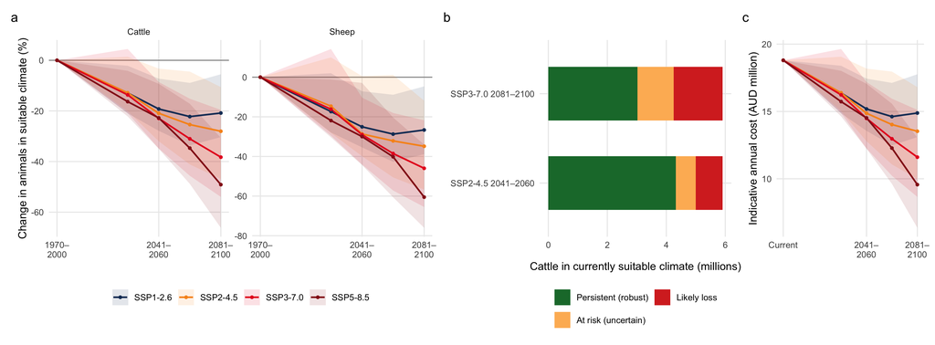

Figure 1: Livestock exposure (Extension 1). (a) Change in the number of cattle and sheep in climatically suitable areas relative to current climate (lines: median across ten GCMs; ribbons: range). (b) Cattle in currently suitable climate by management category of `code_7` for the two focal scenarios. (c) Indicative annual cost of theileriosis to Australian cattle producers, scaling the 2022 estimate of AUD 18.8 million (Shephard et al. 2022) by the number of exposed cattle.

```r
ex_t <- expo_ens |> filter(group %in% c("Cattle", "Sheep")) |>
  mutate(year = per_mid[as.character(period)], lab = group) |>
  bind_rows(expo_ens |> filter(group %in% c("Cattle", "Sheep")) |> distinct(group, unit, ssp_l) |>
              mutate(year = 1985, pct_med = 0, pct_lo = 0, pct_hi = 0, lab = group))
p_ex <- ggplot(ex_t, aes(year, pct_med, colour = ssp_l, fill = ssp_l)) + geom_hline(yintercept = 0, colour = "grey60") +
  geom_ribbon(aes(ymin = pct_lo, ymax = pct_hi), alpha = 0.12, colour = NA) + geom_line(linewidth = 0.8) + geom_point(size = 1.1) +
  facet_wrap(~ lab, nrow = 1, scales = "free_y") + scale_colour_manual(values = ssp_col, name = NULL) + scale_fill_manual(values = ssp_col, name = NULL) +
  scale_x_continuous(breaks = c(1985, 2050.5, 2090.5), labels = c("1970–\n2000", "2041–\n2060", "2081–\n2100")) +
  labs(x = NULL, y = "Change in animals in suitable climate (%)", tag = "a") + theme(legend.position = "bottom")
mg_lv <- c("Persistent (robust)", "At risk (uncertain)", "Likely loss")
p_mg <- mg_cattle |> filter(class %in% mg_lv) |> mutate(class = factor(class, levels = rev(mg_lv))) |>
  ggplot(aes(cattle / 1e6, scenario, fill = class)) + geom_col(width = 0.6) +
  scale_fill_manual(values = c("Persistent (robust)" = "#1b7837", "At risk (uncertain)" = "#fdb863", "Likely loss" = "#d73027"), name = NULL) +
  labs(x = "Cattle in currently suitable climate (millions)", y = NULL, tag = "b") + theme(legend.position = "bottom") + guides(fill = guide_legend(nrow = 2, reverse = TRUE))
p_ct <- cost_proj |> mutate(year = per_mid[as.character(period)]) |>
  bind_rows(tibble(ssp_l = factor(ssp_lab, levels = ssp_lab), year = 1985, med = cost_au, lo = cost_au, hi = cost_au)) |>
  ggplot(aes(year, med / 1e6, colour = ssp_l, fill = ssp_l)) + geom_ribbon(aes(ymin = lo / 1e6, ymax = hi / 1e6), alpha = 0.12, colour = NA) +
  geom_line(linewidth = 0.8) + geom_point(size = 1.1) + scale_colour_manual(values = ssp_col, guide = "none") + scale_fill_manual(values = ssp_col, guide = "none") +
  scale_x_continuous(breaks = c(1985, 2050.5, 2090.5), labels = c("Current", "2041–\n2060", "2081–\n2100")) +
  labs(x = NULL, y = "Indicative annual cost (AUD million)", tag = "c")
p_ex + p_mg + p_ct + plot_layout(widths = c(2.6, 1.3, 1))
save_fig("Fig1_livestock_exposure", w = 13, h = 4.8)
```

```r
cell <- function(m, l, h, d = 1) sprintf("%s [%s, %s]", fmt(m, d), fmt(l, d), fmt(h, d))
sel_sc <- tibble(ssp = c("245", "245", "370", "585"), period = c("2041-2060", "2081-2100", "2081-2100", "2081-2100"))
cur_row <- expo_ens |> filter(group %in% c("Cattle", "Sheep", "People")) |> distinct(group, unit, exposed_cur) |>
  transmute(group, unit, Scenario = "Current", v = fmt(exposed_cur / 1e6, 1))
fut_rows <- expo_ens |> filter(group %in% c("Cattle", "Sheep", "People")) |> semi_join(sel_sc, by = c("ssp", "period")) |>
  transmute(group, unit, Scenario = paste(ssp_l, gsub("-", "–", period)), v = cell(med / 1e6, lo / 1e6, hi / 1e6))
cost_rows <- bind_rows(tibble(Scenario = "Current", v = fmt(cost_au / 1e6, 1)),
  cost_proj |> mutate(ssp = names(ssp_lab)[match(as.character(ssp_l), ssp_lab)]) |> semi_join(sel_sc, by = c("ssp", "period")) |>
    transmute(Scenario = paste(ssp_l, gsub("-", "–", period)), v = cell(med / 1e6, lo / 1e6, hi / 1e6))) |>
  mutate(group = "Cost", unit = "Australia")
bind_rows(cur_row, fut_rows, cost_rows) |>
  mutate(col = recode(group, Cost = "Theileriosis cost, AUD M", People = "People", Cattle = "Cattle", Sheep = "Sheep")) |>
  dplyr::select(Scenario, col, v) |> pivot_wider(names_from = col, values_from = v) |>
  dplyr::select(Scenario, starts_with("Cattle"), starts_with("Sheep"), starts_with("People"), starts_with("Theileriosis")) |>
  kable(align = "lrrrr")
```

Table 1: Cattle, sheep and people in climatically suitable areas (millions; median and range across ten GCMs) and the indicative annual cost of theileriosis to Australian cattle producers (AUD million; scaled from Shephard et al. (2022)). Livestock: GLW3 (2010); people: GPW v4 (2020), both held constant.

| Scenario | Cattle | Sheep | People | Theileriosis cost, AUD M |
| --- | --- | --- | --- | --- |
| Current | 5.9 | 9.3 | 15.2 | 18.8 |
| SSP2-4.5 2041–2060 | 4.7 [4.0, 5.7] | 6.7 [5.6, 9.4] | 12.0 [10.7, 14.2] | 14.9 [12.8, 18.2] |
| SSP2-4.5 2081–2100 | 4.3 [3.1, 5.3] | 6.1 [4.0, 8.2] | 10.8 [9.1, 13.2] | 13.5 [10.0, 16.8] |
| SSP3-7.0 2081–2100 | 3.6 [2.7, 4.8] | 5.0 [3.2, 7.3] | 9.3 [6.8, 11.2] | 11.6 [8.7, 15.1] |
| SSP5-8.5 2081–2100 | 3.0 [2.0, 4.1] | 3.7 [2.2, 6.2] | 7.5 [1.8, 9.7] | 9.6 [6.4, 13.0] |

## 3.2 Extension 2: introduction pressure and establishment risk

626 of 11616 0.25° units were classed as infested. Introduction pressure, the potential inflow of ticks with cattle from these units, is highest immediately inland of the infested coastal belt in New South Wales and Victoria. It is lowest in Western Australia and, because of the sea crossing, in Tasmania (Figure 2). Combined with climatic suitability, establishment risk is concentrated in two areas: (i) western Victoria (the Western District and Glenelg region) and the adjacent south-east of South Australia; and (ii) isolated suitable units on the New England Tablelands and in south-east Queensland adjacent to the infested range. Tasmania is climatically suitable throughout but carries only 3.1% of the total establishment risk under the primary sea-crossing penalty, rising to 13.9% if movements across Bass Strait are five times more likely. The ranking was robust to the kernel parameters (ρ ≥ 0.97; ≥ 73% overlap of the top-100 units; Table S3).

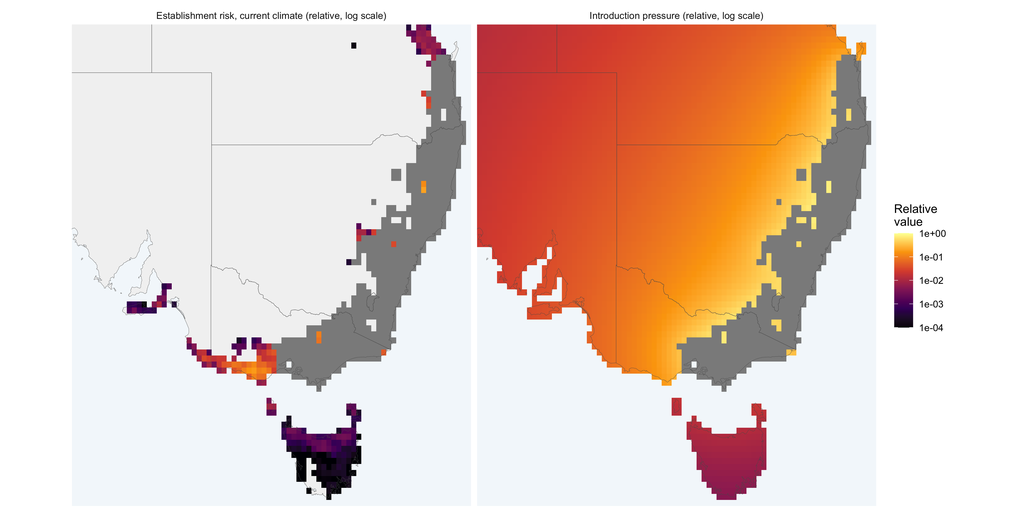

Figure 2: Introduction pressure and establishment risk (Extension 2), 0.25° units. Left: establishment risk, the product of expected introductions (pressure × destination cattle) and current climatic suitability. Right: relative pressure of tick introduction with cattle from the infested range. Grey units are infested (suitable and within 100 km of a known record). Both quantities are scaled to their maximum and shown on a log scale.

```r
se_base <- list(coord_sf(xlim = c(134, 154), ylim = c(-44, -24), expand = FALSE), labs(x = NULL, y = NULL),
                theme(panel.background = element_rect(fill = "#f4f8fb", colour = NA), axis.text = element_blank(), panel.grid = element_blank()))
u_long <- units |> mutate(pressure_rel = pressure / max(pressure)) |>
  transmute(x, y, infested, `Introduction pressure (relative, log scale)` = ifelse(infested, NA, pressure_rel),
            `Establishment risk, current climate (relative, log scale)` = ifelse(infested | risk_cur <= 0, NA, risk_cur / max(risk_cur))) |>
  pivot_longer(-c(x, y, infested), names_to = "panel")
ggplot() + geom_sf(data = aus_sf, fill = "grey95", colour = NA) +
  geom_tile(data = filter(u_long, infested), aes(x, y), fill = "grey55", width = 0.25, height = 0.25) +
  geom_tile(data = filter(u_long, !infested, !is.na(value)), aes(x, y, fill = value), width = 0.25, height = 0.25) +
  geom_sf(data = jur, fill = NA, colour = "grey35", linewidth = 0.1) +
  scale_fill_viridis_c(option = "inferno", trans = "log10", limits = c(1e-4, 1), oob = scales::squish, name = "Relative\nvalue") +
  facet_wrap(~ panel) + se_base
save_fig("Fig2_introduction_establishment_risk", w = 13, h = 6.5)
```

## 3.3 Extension 3: process-based model

The two model types disagree about the future. In the process model, physiologically suitable area changes by only −16% by 2041–2060 under SSP2-4.5 and −30% by 2081–2100 under SSP3-7.0. Only 31–41% of the area that the SDM projects to lose is also lost in the process model, mainly along the inland margin where dry-stress months increase. In the persistent core, warming lengthens the nymph and adult questing season by 1.2 months by 2041–2060 under SSP2-4.5 and by 2.4 months by 2081–2100 under SSP3-7.0. It also increases the potential generation rate by 0.46 and 1.00 generations per year (Figure 3 c). The largest increases in season length are in Tasmania and the Victorian highlands, where activity is currently limited by cold.

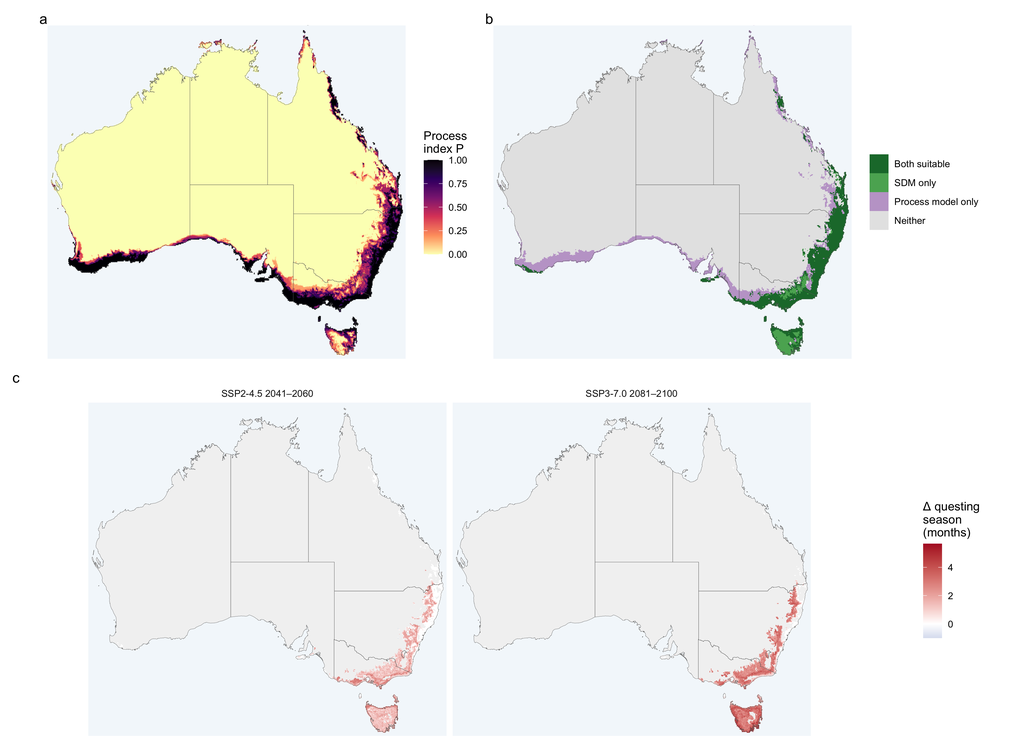

Figure 3: Process-based model (Extension 3). (a) Life-cycle feasibility index *P* under current climate. (b) Agreement between the process model (*P* ≥ 0.5) and the SDM. (c) Change in the length of the nymph and adult questing season (months) within the persistent core range (≥ 80% of GCMs suitable) for the two focal scenarios (median across ten GCMs).

```r
agr_lab <- c("Both suitable", "SDM only", "Process model only", "Neither")
agr <- ifelse(bin_cur & pm_cur$P >= thr_P, 1L, ifelse(bin_cur, 2L, ifelse(pm_cur$P >= thr_P, 3L, 4L)))
p_P <- ggplot(map_df(list(a = pm_cur$P), tibble(key = "a"))) + geom_raster(aes(x, y, fill = value)) +
  geom_sf(data = aus_sf, fill = NA, colour = "grey40", linewidth = 0.1) +
  scale_fill_viridis_c(option = "magma", direction = -1, limits = c(0, 1), name = "Process\nindex P") + map_base + labs(tag = "a")
p_ag <- ggplot(map_df(list(a = agr), tibble(key = "a"), fun = "modal") |> mutate(v = factor(agr_lab[value], levels = agr_lab))) +
  geom_raster(aes(x, y, fill = v)) + geom_sf(data = aus_sf, fill = NA, colour = "grey40", linewidth = 0.1) +
  scale_fill_manual(values = c("Both suitable" = "#1b7837", "SDM only" = "#5aae61", "Process model only" = "#c2a5cf", Neither = "grey90"), name = NULL) +
  map_base + labs(tag = "b")
core_k <- function(k) bin_cur & agree(k) >= 0.8
dM <- map_df(setNames(lapply(c("245_2041-2060", "370_2081-2100"), function(k) ifelse(core_k(k), pm_ens[[k]]$M_a - pm_cur$M_a, NA)),
                      c("245_2041-2060", "370_2081-2100")), tibble(key = c("245_2041-2060", "370_2081-2100"), panel = focal_lab))
p_dM <- ggplot(dM) + geom_sf(data = aus_sf, fill = "grey95", colour = NA) + geom_raster(aes(x, y, fill = value)) +
  geom_sf(data = aus_sf, fill = NA, colour = "grey40", linewidth = 0.1) +
  scale_fill_gradient2(low = "#2166ac", high = "#b2182b", name = "Δ questing\nseason\n(months)") + facet_wrap(~ panel) + map_base + labs(tag = "c")
(p_P + p_ag) / p_dM
save_fig("Fig3_process_model", w = 13, h = 9.5)
```

## 3.4 Extension 4: microclimatic refugia

Of the 67 × 10³ km² projected to lose suitability by 2041–2060 under SSP2-4.5, 7.6 × 10³ km² (11%) retains suitable cooler sub-cells after topographic downscaling. Under SSP3-7.0 in 2081–2100, the figures are 9.1 of 135 × 10³ km² (7%; Figure 4, Table S5). Topographic refugia occur mainly in the ranges of south-east Queensland and north-east New South Wales and on the Atherton Tableland, where loss cells contain valleys and slopes several hundred metres higher than the cell mean. Irrigation is a potential refuge on a further 8.3 × 10³ km² (SSP2-4.5 2041–2060), mostly irrigated dairy and mixed farming land in south-west Victoria, Gippsland (Macalister district), south-east South Australia and the Tasmanian midlands. Tree cover ≥ 30% applies to much of the forested subcoastal land of New South Wales and Queensland. Taking all three types together, 75% of the area of projected loss under SSP2-4.5 2041–2060 contains at least one potential refuge type, whereas 16.6 × 10³ km² (mostly cleared, unirrigated pasture on the inland and western margin) has none.

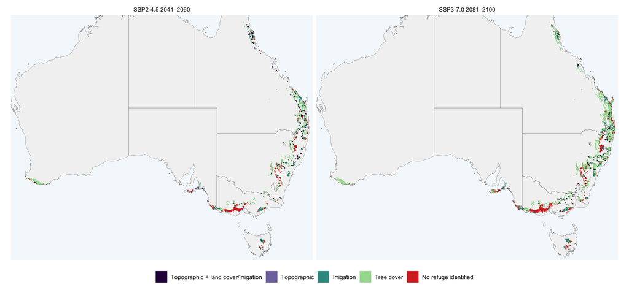

Figure 4: Potential microclimatic refugia within areas projected to lose climatic suitability (Extension 4). *Topographic*: ≥ 10% of 30″ sub-cells remain suitable after lapse-rate downscaling of temperature; *irrigation*: ≥ 5% of the cell equipped for irrigation; *tree cover*: ≥ 30% tree cover; categories are hierarchical.

```r
ref_lv <- c("Topographic + land cover/irrigation", "Topographic", "Irrigation", "Tree cover", "No refuge identified")
ref_col <- c("Topographic + land cover/irrigation" = "#2d004b", "Topographic" = "#8073ac", Irrigation = "#35978f",
             "Tree cover" = "#a6dba0", "No refuge identified" = "#d73027")
d_ref <- map_df(setNames(lapply(focal, function(k) match(refugia_class(k), ref_lv)), focal),
                tibble(key = focal, panel = focal_lab), fun = "modal") |> mutate(cls = factor(ref_lv[value], levels = ref_lv))
ggplot(d_ref) + geom_sf(data = aus_sf, fill = "grey95", colour = NA) + geom_raster(aes(x, y, fill = cls)) +
  geom_sf(data = jur, fill = NA, colour = "grey35", linewidth = 0.1) + scale_fill_manual(values = ref_col, name = NULL, drop = FALSE) +
  facet_wrap(~ panel) + coord_sf(xlim = c(113, 154), ylim = c(-44, -15), expand = FALSE) + labs(x = NULL, y = NULL) +
  theme(panel.background = element_rect(fill = "#f4f8fb", colour = NA), axis.text = element_blank(), panel.grid = element_blank(),
        legend.position = "bottom")
save_fig("Fig4_refugia", w = 13, h = 6)
```

## 3.5 Extension 5: global warming levels

Expressed against global warming, the projections collapse onto a single, roughly linear relationship for Australia, irrespective of emissions scenario or period (Figure 5 a). Suitable area in Australia changes by −12% at 1.5 °C, −16% at 2 °C, −24% at 3 °C and −36% at 4 °C of global warming (Table 2). Cattle exposure falls faster, changing by −19% at 2 °C and −27% at 3 °C. The share of known localities that remain suitable falls from 73% at 1.5 °C to 61% at 3 °C. The spatial pattern at each warming level is the same contraction from the warm and dry margins seen in `code_7` (Figure 5 b). In the ten core GCMs, the median year of reaching 2 °C is 2043 under SSP2-4.5 and 2044 under SSP3-7.0, and 3 °C is reached in 6 of 10 GCMs under SSP2-4.5 by the end of the century (Table S6).

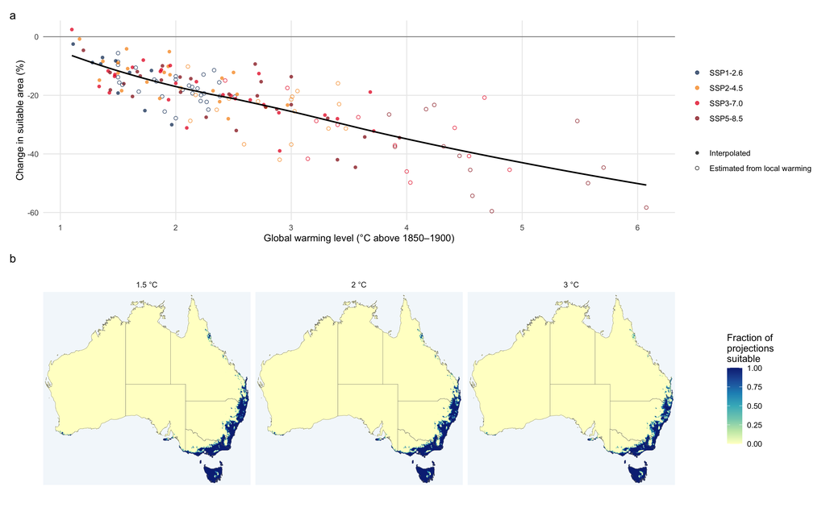

Figure 5: Projections at global warming levels (Extension 5). (a) Change in climatically suitable area against the global warming level of each GCM × SSP × period (relative to 1850–1900); the line is a LOESS smooth. Open symbols: warming level estimated from local warming because the period lies beyond the last tabulated crossing. (b) Fraction of projections within ±0.25 °C of each warming level that are climatically suitable.

```r
p_gs <- gwl_tab |> filter(set == "core") |>
  ggplot(aes(gwl, pct_change)) + geom_hline(yintercept = 0, colour = "grey60") +
  geom_point(aes(colour = ssp_l, shape = gwl_capped), alpha = 0.75, size = 1.6) +
  geom_smooth(method = "loess", span = 0.9, colour = "black", linewidth = 0.8, se = FALSE) +
  scale_colour_manual(values = ssp_col, name = NULL) + scale_shape_manual(values = c(`FALSE` = 16, `TRUE` = 1), labels = c("Interpolated", "Estimated from local warming"), name = NULL) +
  labs(x = "Global warming level (°C above 1850–1900)", y = "Change in suitable area (%)", tag = "a") +
  theme(legend.position = "right")
d_gm <- map_df(setNames(gwl_maps, paste0("g", names(gwl_maps))), tibble(key = paste0("g", names(gwl_maps)), panel = paste0(names(gwl_maps), " °C")))
p_gm <- ggplot(d_gm) + geom_raster(aes(x, y, fill = value)) +
  geom_sf(data = aus_sf, fill = NA, colour = "grey40", linewidth = 0.1) +
  scale_fill_distiller(palette = "YlGnBu", direction = 1, limits = c(0, 1), name = "Fraction of\nprojections\nsuitable") +
  facet_wrap(~ panel, nrow = 1) + map_base + labs(tag = "b")
p_gs / p_gm + plot_layout(heights = c(1, 1.1))
save_fig("Fig5_global_warming_levels", w = 13, h = 8)
```

```r
gwl_sum |>
  transmute(`Warming level` = paste0(gwl, " °C"), `Projections` = n,
            `Change in suitable area (%)` = sprintf("%s [%s, %s]", sgn(med), sgn(lo), sgn(hi)),
            `Change in cattle exposed (%)` = sgn(cattle), `Known localities suitable (%)` = fmt(known, 0)) |>
  kable(align = "lrrrr")
```

Table 2: Change in climatically suitable area, cattle exposure and known localities remaining suitable at global warming levels (median and 10th–90th percentile across GCM × SSP × period combinations within ±0.25 °C of each level).

| Warming level | Projections | Change in suitable area (%) | Change in cattle exposed (%) | Known localities suitable (%) |
| --- | --- | --- | --- | --- |
| 1.5 °C | 36 | −12 [−19, −8] | −14 | 73 |
| 2 °C | 40 | −16 [−26, −10] | −19 | 69 |
| 3 °C | 18 | −24 [−40, −18] | −27 | 61 |
| 4 °C | 8 | −36 [−47, −24] | −39 | 50 |

## 3.6 Extension 7: surveillance design

290 units were candidates for surveillance. Risk-based allocation was much more efficient than the alternatives (Figure 6 a). With five undetected populations and a 30% chance that a visit detects an existing population, 100 risk-allocated visits detect at least one population with probability 0.94, compared with 0.84 for allocation proportional to cattle and 0.46 for uniform allocation. Uniform allocation needs more than five times as many visits to match 100 risk-based visits. The advantage persists across assumed numbers of undetected populations and detection probabilities. In the reference design (250 visits), 54 units receive visits; 204 of the visits go to Victoria, 26 to New South Wales and 13 to South Australia (Figure 6 b, Table 3, Table S4). If all visits are negative, the expected number of undetected populations among candidate units falls from 5.0 to 1.2, and the posterior probability of presence in each visited unit falls below 0.02 (Figure S4). Tasmania receives 0 visits under the primary gravity model, because modelled introduction pressure across Bass Strait is low. This allocation depends on the sea-crossing assumption, and Tasmania’s large suitable area makes a modest allocation prudent (see Discussion).

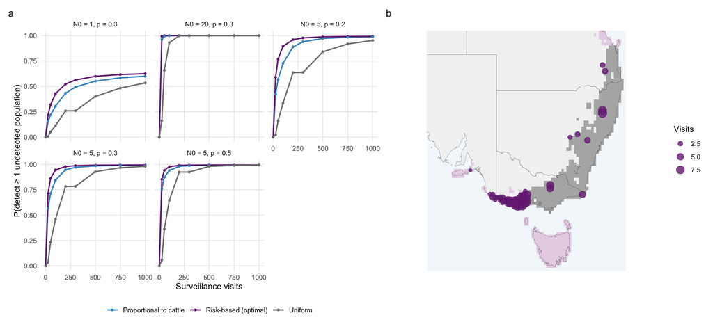

Figure 6: Surveillance design (Extension 7). (a) Probability of detecting at least one undetected population against the number of surveillance visits for risk-based (optimal), cattle-proportional and uniform allocation, for several assumed numbers of undetected populations (N0) and per-visit detection probabilities (p). (b) Risk-based allocation of 250 visits (N0 = 5, p = 0.3); pale purple: candidate units; grey: infested units.

```r
p_sc <- surv_curve |> filter(p == 0.3 | N0 == 5) |>
  mutate(panel = sprintf("N0 = %s, p = %s", N0, p)) |>
  ggplot(aes(budget, p_any, colour = strategy)) + geom_line(linewidth = 0.8) + geom_point(size = 1) +
  facet_wrap(~ panel, ncol = 3) + scale_colour_manual(values = c("Risk-based (optimal)" = "#762a83", "Proportional to cattle" = "#4393c3", Uniform = "grey50"), name = NULL) +
  labs(x = "Surveillance visits", y = "P(detect ≥ 1 undetected population)", tag = "a") + theme(legend.position = "bottom")
p_alloc <- ggplot() + geom_sf(data = aus_sf, fill = "grey95", colour = NA) +
  geom_tile(data = filter(units, infested), aes(x, y), fill = "grey70", width = 0.25, height = 0.25) +
  geom_tile(data = cand, aes(x, y), fill = "#e7d4e8", width = 0.25, height = 0.25) +
  geom_point(data = filter(cand, visits > 0), aes(x, y, size = visits), colour = "#762a83", alpha = 0.8) +
  geom_sf(data = jur, fill = NA, colour = "grey35", linewidth = 0.1) + scale_size_area(max_size = 5, name = "Visits") +
  se_base + labs(tag = "b")
p_sc + p_alloc + plot_layout(widths = c(1.25, 1))
save_fig("Fig6_surveillance_design", w = 13, h = 6)
```

```r
cand |> arrange(desc(visits), desc(pi)) |> head(15) |>
  transmute(`State or territory` = jur, `Lon` = fmt(x, 2), `Lat` = fmt(y, 2), `Cattle (10³)` = fmt(cattle / 1000, 1),
            `Distance to known record (km)` = fmt(d_known, 0), `Prior` = fmt(pi, 3), `Visits` = visits, `Posterior` = fmt(post, 3)) |>
  kable(align = "lrrrrrrr")
```

Table 3: The 15 highest-ranked candidate surveillance units in the reference design (250 visits; N0 = 5; p = 0.3): prior probability of an undetected population, allocated visits and posterior probability if all visits are negative.

| State or territory | Lon | Lat | Cattle (10³) | Distance to known record (km) | Prior | Visits | Posterior |
| --- | --- | --- | --- | --- | --- | --- | --- |
| New South Wales | 151.62 | -30.87 | 23.0 | 107 | 0.275 | 9 | 0.015 |
| Victoria | 143.12 | -38.37 | 64.8 | 201 | 0.250 | 9 | 0.013 |
| Victoria | 142.87 | -38.37 | 63.6 | 223 | 0.223 | 9 | 0.011 |
| New South Wales | 151.62 | -30.62 | 17.4 | 104 | 0.189 | 8 | 0.013 |
| Victoria | 143.12 | -38.12 | 52.3 | 199 | 0.181 | 8 | 0.013 |
| Victoria | 143.62 | -38.37 | 33.1 | 158 | 0.173 | 8 | 0.012 |
| Victoria | 143.12 | -38.62 | 43.5 | 207 | 0.169 | 8 | 0.012 |
| Victoria | 142.62 | -38.37 | 47.8 | 245 | 0.157 | 7 | 0.015 |
| Victoria | 143.37 | -38.37 | 33.2 | 180 | 0.153 | 7 | 0.015 |
| Victoria | 146.37 | -36.87 | 11.4 | 103 | 0.150 | 7 | 0.014 |
| Victoria | 142.12 | -38.12 | 47.3 | 287 | 0.129 | 7 | 0.012 |
| Victoria | 143.87 | -38.37 | 20.6 | 137 | 0.128 | 7 | 0.012 |
| Victoria | 142.87 | -38.12 | 57.4 | 221 | 0.127 | 7 | 0.012 |
| Victoria | 146.37 | -37.12 | 7.6 | 102 | 0.119 | 6 | 0.016 |
| Victoria | 142.37 | -38.12 | 50.2 | 265 | 0.117 | 6 | 0.015 |

# 4 Discussion

## 4.2 Introduction pressure, not climate, will determine new incursions

Climate change opens almost no new climatically suitable area (`code_7`), so new incursions will occur in places that are already suitable but not yet infested. The gravity model ranks these by the potential flow of cattle from infested districts. The Western District of Victoria and the New England Tablelands of New South Wales stand out because they combine suitable climate, large cattle populations and proximity to infested areas. These areas also coincide with the surveillance gaps identified in `code_6`. The model is deliberately simple. Replacing the distance kernel with observed movement networks from NLIS, and adding movements of wildlife hosts, would substantially improve the risk estimates.

## 4.3 The process model confirms where the tick can live but questions how fast it will retreat

The process-based model is built from laboratory thresholds and field tolerances, not from occurrence records. That it reproduces the known distribution almost as well as the SDM confirms that the correlative model has captured real physiological limits: dry-season desiccation inland, cold in the south and at altitude, and an annual life cycle across the core. Its future projections, however, show much less contraction than the SDM. The difference lies at the warm margin. The SDM has learned from the native and invaded ranges that suitability declines above about 15–20 °C mean annual temperature, whereas the process model contains no thermal penalty below the heat-stress threshold, and in it warming simply accelerates development. Either the SDM’s warm-side decline reflects processes absent from the process model (for example warm-season mortality of eggs and unfed larvae at high temperature and humidity, disruption of the diapause that synchronises the life cycle, competition with other ticks, or host changes), or it partly reflects the limited sampling of hot climates in the calibration data. Field monitoring of tick abundance along the northern margin is the most direct way to discriminate between these explanations. Until then, the SDM losses at the warm margin should be treated as an upper bound. The process model’s projections of seasonality are more robust: in the core range, the questing season lengthens by one to two and a half months and the potential number of generations increases. Both have practical consequences for the timing and frequency of acaricide treatment and for the period during which calves are exposed to *T. orientalis*.

## 4.4 Refugia and warming levels refine the projected losses

Topographic refugia would retain suitable microsites in about one-tenth of the area projected to be lost, and irrigation and forest cover could buffer considerably more. These estimates are crude: the downscaling adjusts only temperature, and the moisture effects of irrigation and canopy are flagged, not modelled. They indicate that losses at the margins will be patchy rather than complete, and that irrigated dairy districts in south-west Victoria and Gippsland are where persistence despite regional drying is most likely. Expressed at global warming levels, the Australian projections fall on a single curve, roughly a 12% loss of suitable area at 1.5 °C, 16% at 2 °C and 24% at 3 °C. This makes them directly usable with national climate-risk frameworks, which are increasingly framed by warming level rather than by emissions scenario.

## 4.6 Limitations

Livestock and population layers are fixed at 2010 and 2020, respectively. GLW3 places about 0% of Australian cattle outside the land grid of the SDM (coastal cells), so exposure is slightly underestimated. The gravity model uses distance as a proxy for movement. The process model uses monthly climatologies and a simplified life-cycle structure without diapause or host-finding, and two of its structural choices were made after inspecting results (see Methods, Extension 3). The surveillance model treats units as independent and assumes perfect specificity. For all extensions, the uncertainties described in `code_6` and `code_7` (SDM, GCM and scenario) apply in addition.

## 4.7 Conclusions

The tick’s future in Australia will be decided less by climate change, which removes suitable climate at the margins but adds almost none, than by the movement of cattle into suitable areas that are not yet infested, and by changes in seasonal activity within the persistent core. For managers, the priorities that follow are: (i) maintain theileriosis control across the persistent core under all scenarios; (ii) target surveillance at the Western District of Victoria, the New England Tablelands and, as a precaution, Tasmania; (iii) monitor tick abundance along the northern margin to determine how quickly suitability is declining there; and (iv) adjust treatment timing to the lengthening questing season.

# References

Center for International Earth Science Information Network (CIESIN), Columbia University. 2018. “Gridded Population of the World, Version 4 (GPWv4): Population Density, Revision 11.” NASA Socioeconomic Data and Applications Center (SEDAC), https://doi.org/10.7927/H49C6VHW.

Fick, Stephen E., and Robert J. Hijmans. 2017. “WorldClim 2: New 1-Km Spatial Resolution Climate Surfaces for Global Land Areas.” *International Journal of Climatology* 37: 4302–15.

Gilbert, Marius, Gaëlle Nicolas, Giusepina Cinardi, Thomas P. Van Boeckel, Sophie O. Vanwambeke, G. R. William Wint, and Timothy P. Robinson. 2018. “Global Distribution Data for Cattle, Buffaloes, Horses, Sheep, Goats, Pigs, Chickens and Ducks in 2010.” *Scientific Data* 5: 180227.

Hauser, Mathias, Francois Engelbrecht, and Erich M. Fischer. 2022. “Transient Global Warming Levels for CMIP5 and CMIP6 (V0.3.0).” Zenodo, https://doi.org/10.5281/zenodo.7390473.

Heath, Allen. 2016. “Biology, Ecology and Distribution of the Tick, *Haemaphysalis Longicornis* Neumann (Acari: Ixodidae) in New Zealand.” *New Zealand Veterinary Journal* 64: 10–20.

Hoogstraal, Harry, F. H. S. Roberts, Glen M. Kohls, and Vernon J. Tipton. 1968. “Review of *Haemaphysalis* (*Kaiseriana*) *Longicornis* Neumann (Resurrected) of Australia, New Zealand, New Caledonia, Fiji, Japan, Korea, and Northeastern China and USSR, and Its Parthenogenetic and Bisexual Populations (Ixodoidea, Ixodidae).” *Journal of Parasitology* 54: 1197–1213.

Kamau, Joseph, Albert J. de Vos, Martin Playford, Basima Salim, Peter Kinyanjui, and Chihiro Sugimoto. 2011. “Emergence of New Types of *Theileria Orientalis* in Australian Cattle and Possible Cause of Theileriosis Outbreaks.” *Parasites & Vectors* 4: 22.

Needham, Glen R., and Pete D. Teel. 1991. “Off-Host Physiological Ecology of Ixodid Ticks.” *Annual Review of Entomology* 36: 659–81.

Ogden, Nick H., and L. Robbin Lindsay. 2016. “Effects of Climate and Climate Change on Vectors and Vector-Borne Diseases: Ticks Are Different.” *Trends in Parasitology* 32: 646–56.

Schappach, Brittany L., Rayda K. Krell, Victoria L. Hornbostel, and Neeta P. Connally. 2020. “Exotic *Haemaphysalis Longicornis* (Acari: Ixodidae) in the United States: Biology, Ecology, and Strategies for Management.” *Journal of Integrated Pest Management* 11: 21.

Shephard, Richard, John Webb Ware, Ben Blomfield, and Geoff Niethe. 2022. “Priority List of Endemic Diseases for the Red Meat Industry – 2022 Update. Final Report B.AHE.0327.” North Sydney: Meat & Livestock Australia.

Siebert, Stefan, Verena Henrich, Karen Frenken, and Jacob Burke. 2013. “Update of the Digital Global Map of Irrigation Areas to Version 5.” Rheinische Friedrich-Wilhelms-Universität, Bonn,; Food; Agriculture Organization of the United Nations, Rome.

Yano, Yasuyuki, Satoshi Shiraishi, and Teru A. Uchida. 1987. “Effects of Temperature on Development and Growth in the Tick, *Haemaphysalis Longicornis*.” *Experimental and Applied Acarology* 3: 73–78.

Yu, Xue-Jie, Mi-Fang Liang, Shou-Yin Zhang, Yan Liu, Jian-Dong Li, Yu-Lan Sun, Lihong Zhang, et al. 2011. “Fever with Thrombocytopenia Associated with a Novel Bunyavirus in China.” *New England Journal of Medicine* 364: 1523–32.

Zanaga, Daniele, Ruben Van De Kerchove, Wanda De Keersmaecker, Niels Souverijns, et al. 2021. “ESA WorldCover 10 m 2020 V100.” Zenodo, https://doi.org/10.5281/zenodo.5571936.

## 5 Supplementary material

## 5.1 Supplementary tables

```r
stage |> transmute(Stage = stage, `Lower threshold (°C)` = T0, `Duration at 25 °C (d)` = days25, `Thermal constant (degree-days)` = round(K)) |>
  bind_rows(tibble(Stage = "Total", `Thermal constant (degree-days)` = round(sum(stage$K)))) |> kable()
```

| Stage | Lower threshold (°C) | Duration at 25 °C (d) | Thermal constant (degree-days) |
| --- | --- | --- | --- |
| Pre-oviposition + oviposition | 11.1 | 7 | 97 |
| Egg incubation | 12.2 | 25 | 320 |
| Larval moult | 10.2 | 14 | 207 |
| Nymphal moult | 11.8 | 17 | 224 |
| Total |  |  | 849 |

Table S1: Parameters of the process-based model. Thresholds: Yano, Shiraishi, and Uchida (1987). Durations: Heath (2016) as summarised by Schappach et al. (2020); the pre-oviposition plus oviposition duration is assumed. Moisture: larval questing requires a saturation deficit ≤ 10 mmHg and nymph/adult questing ≤ 20 mmHg (Heath 2016); heat stress: mean daily maximum ≥ 35 °C.

```r
pm_auc |> transmute(Region = recode(region, East_Asia = "East Asia", North_America = "North America"), `Records` = n,
                    `AUC, index P` = fmt(auc_P), `AUC, generation rate G only` = fmt(auc_G)) |> kable()
```

```r
sens_K |> transmute(`Saturation deficit at` = sd_at, `Thermal constants ×` = K_mult, `Larval SD limit (mmHg)` = sd_larva,
                    `Questing months required` = M_min, `Dry-stress SD limit (mmHg)` = sd_adult,
                    `Dry months for zero survival` = ifelse(is.na(D_max), "no dry term", as.character(D_max)), AUC = fmt(auc), `Area P ≥ 0.5 (10³ km²)` = fmt(area_P05 / 1000, 0),
                    `Agreement with SDM` = fmt(agree_sdm), `Known localities P ≥ 0.5` = fmt(known_ok)) |> kable()
```

| Region | Records | AUC, index P | AUC, generation rate G only |
| --- | --- | --- | --- |
| East Asia | 215 | 0.66 | 0.59 |
| North America | 53 | 0.68 | 0.56 |
| Oceania | 121 | 0.91 | 0.20 |
| All | 389 | 0.75 | 0.51 |
| Australia (subset of Oceania) | 66 | 0.91 | 0.19 |

| Saturation deficit at | Thermal constants × | Larval SD limit (mmHg) | Questing months required | Dry-stress SD limit (mmHg) | Dry months for zero survival | AUC | Area P ≥ 0.5 (10³ km²) | Agreement with SDM | Known localities P ≥ 0.5 |
| --- | --- | --- | --- | --- | --- | --- | --- | --- | --- |
| max | 0.7 | 8 | 4 | 20 | 3 | 0.67 | 397 | 0.95 | 0.55 |
| max | 0.7 | 10 | 4 | 20 | 3 | 0.74 | 653 | 0.95 | 0.87 |
| max | 0.7 | 15 | 4 | 20 | 3 | 0.75 | 848 | 0.93 | 0.93 |
| max | 1.0 | 8 | 4 | 20 | 3 | 0.67 | 364 | 0.95 | 0.55 |
| max | 1.0 | 10 | 4 | 20 | 3 | 0.75 | 619 | 0.95 | 0.87 |
| max | 1.0 | 15 | 4 | 20 | 3 | 0.77 | 822 | 0.93 | 0.93 |
| max | 1.3 | 8 | 4 | 20 | 3 | 0.67 | 337 | 0.95 | 0.55 |
| max | 1.3 | 10 | 4 | 20 | 3 | 0.76 | 580 | 0.94 | 0.87 |
| max | 1.3 | 15 | 4 | 20 | 3 | 0.77 | 793 | 0.92 | 0.93 |
| max | 1.0 | 10 | 3 | 20 | 3 | 0.76 | 626 | 0.95 | 0.87 |
| max | 1.0 | 10 | 6 | 20 | 3 | 0.76 | 459 | 0.95 | 0.75 |
| max | 1.0 | 10 | 4 | 25 | 3 | 0.74 | 1028 | 0.89 | 0.92 |
| max | 1.0 | 10 | 4 | 20 | 6 | 0.75 | 764 | 0.93 | 0.89 |
| max | 1.0 | 10 | 4 | 20 | no dry term | 0.73 | 1818 | 0.79 | 0.93 |
| mean | 1.0 | 10 | 4 | 20 | 3 | 0.68 | 3062 | 0.63 | 1.00 |

Table S2: Evaluation of the process-based model. Top: discrimination of occurrence records from the `code_3`/`code_6` evaluation background in each calibration region and for Australian records alone. Bottom: sensitivity to the formulation and parameters (primary specification: maximum, ×1, 10 mmHg, 4 months, 20 mmHg, 3 months).

```r
sens_gamma |> transmute(`γ` = gamma, `d0 (km)` = d0, `Sea-crossing penalty` = ifelse(is.na(sea_penalty), 0.1, sea_penalty),
                        `Spearman ρ with primary pressure` = fmt(rho_pressure, 3), `Overlap of top-100 risk units` = fmt(top100_overlap)) |> kable()
```

| γ | d0 (km) | Sea-crossing penalty | Spearman ρ with primary pressure | Overlap of top-100 risk units |
| --- | --- | --- | --- | --- |
| 1.0 | 50 | 0.1 | 0.972 | 0.94 |
| 1.5 | 50 | 0.1 | 0.987 | 0.97 |
| 3.0 | 50 | 0.1 | 0.976 | 0.94 |
| 2.0 | 25 | 0.1 | 1.000 | 1.00 |
| 2.0 | 100 | 0.1 | 0.999 | 0.98 |
| 2.0 | 50 | 0.5 | 0.979 | 0.73 |

Table S3: Sensitivity of introduction pressure and establishment risk to the gravity-model parameters (primary: γ = 2, d0 = 50 km, sea-crossing penalty 0.1). With a sea-crossing penalty of 0.5 instead of 0.1, Tasmania’s share of total establishment risk rises from 3.1% to 13.9%.

```r
surv_jur |> transmute(`State or territory` = jur, `Candidate units` = units, `Visits allocated` = visits,
                      `Expected undetected populations (prior)` = fmt(prior, 2), `Expected after negative surveys` = fmt(posterior, 2),
                      `Cattle in candidate units (10³)` = fmt(cattle / 1000, 0)) |> kable()
```

| State or territory | Candidate units | Visits allocated | Expected undetected populations (prior) | Expected after negative surveys | Cattle in candidate units (10³) |
| --- | --- | --- | --- | --- | --- |
| Victoria | 52 | 204 | 3.73 | 0.59 | 1006 |
| New South Wales | 5 | 26 | 0.58 | 0.07 | 58 |
| South Australia | 32 | 13 | 0.24 | 0.14 | 222 |
| Queensland | 39 | 7 | 0.27 | 0.21 | 191 |
| Tasmania | 161 | 0 | 0.17 | 0.17 | 603 |
| Western Australia | 1 | 0 | 0.00 | 0.00 | 0 |

Table S4: Reference surveillance design (250 visits; N0 = 5; p = 0.3) by jurisdiction.

```r
ref_tab |> transmute(Scenario = scenario, Category = factor(cls, levels = ref_lv), `Area (10³ km²)` = fmt(area / 1000, 1),
                     `Cattle (10³)` = fmt(cattle / 1000, 0)) |> arrange(Scenario, Category) |> kable()
```

```r
ref_lapse |> transmute(Scenario = scenario, `Area of projected loss (10³ km²)` = fmt(loss / 1000, 1),
                       `With topographic refugia, 6.5 °C/km (10³ km²)` = fmt(lapse6.5 / 1000, 1),
                       `With topographic refugia, 5.0 °C/km (10³ km²)` = fmt(lapse5.0 / 1000, 1)) |> kable()
```

| Scenario | Category | Area (10³ km²) | Cattle (10³) |
| --- | --- | --- | --- |
| SSP2-4.5 2041–2060 | Topographic + land cover/irrigation | 7.0 | 90 |
| SSP2-4.5 2041–2060 | Topographic | 0.6 | 8 |
| SSP2-4.5 2041–2060 | Irrigation | 8.3 | 164 |
| SSP2-4.5 2041–2060 | Tree cover | 34.7 | 501 |
| SSP2-4.5 2041–2060 | No refuge identified | 16.6 | 421 |
| SSP3-7.0 2081–2100 | Topographic + land cover/irrigation | 8.4 | 123 |
| SSP3-7.0 2081–2100 | Topographic | 0.7 | 17 |
| SSP3-7.0 2081–2100 | Irrigation | 13.6 | 288 |
| SSP3-7.0 2081–2100 | Tree cover | 82.3 | 1156 |
| SSP3-7.0 2081–2100 | No refuge identified | 30.2 | 696 |

| Scenario | Area of projected loss (10³ km²) | With topographic refugia, 6.5 °C/km (10³ km²) | With topographic refugia, 5.0 °C/km (10³ km²) |
| --- | --- | --- | --- |
| SSP2-4.5 2041–2060 | 67.3 | 7.6 | 5.8 |
| SSP3-7.0 2081–2100 | 135.3 | 9.1 | 6.9 |

Table S5: Potential refugia within areas of projected loss, by category (top) and sensitivity of topographic refugia to the lapse rate (bottom).

```r
gwl_year |> transmute(Scenario = ssp_lab[ssp], `Warming level (°C)` = warming_level, `GCMs reaching it` = n_gcm,
                      `Median year (centre of 20-yr window)` = round(year_med), `Range` = sprintf("%d–%d", round(year_lo), round(year_hi))) |> kable()
```

| Scenario | Warming level (°C) | GCMs reaching it | Median year (centre of 20-yr window) | Range |
| --- | --- | --- | --- | --- |
| SSP1-2.6 | 1.5 | 10 | 2030 | 2012–2064 |
| SSP1-2.6 | 2.0 | 6 | 2040 | 2030–2074 |
| SSP2-4.5 | 1.5 | 10 | 2030 | 2010–2046 |
| SSP2-4.5 | 2.0 | 10 | 2043 | 2032–2074 |
| SSP2-4.5 | 3.0 | 6 | 2070 | 2066–2088 |
| SSP3-7.0 | 1.5 | 10 | 2032 | 2012–2044 |
| SSP3-7.0 | 2.0 | 10 | 2044 | 2032–2060 |
| SSP3-7.0 | 3.0 | 9 | 2066 | 2056–2082 |
| SSP3-7.0 | 4.0 | 5 | 2082 | 2076–2090 |
| SSP5-8.5 | 1.5 | 10 | 2027 | 2012–2040 |
| SSP5-8.5 | 2.0 | 10 | 2039 | 2028–2054 |
| SSP5-8.5 | 3.0 | 10 | 2058 | 2050–2076 |
| SSP5-8.5 | 4.0 | 8 | 2075 | 2066–2084 |

Table S6: Timing of global warming levels in the ten core GCMs (Hauser, Engelbrecht, and Fischer 2022).

```r
cj <- as_tibble(cat_jur$fut) |> mutate(id = scen$id) |> pivot_longer(-id, names_to = "jur", values_to = "cattle") |>
  left_join(dplyr::select(scen, id, ssp, period, set), by = "id") |> filter(set == "core") |>
  semi_join(sel_sc, by = c("ssp", "period")) |> group_by(jur, ssp, period) |> summarise(med = median(cattle), .groups = "drop") |>
  mutate(col = paste(ssp_lab[ssp], gsub("-", "–", period))) |> dplyr::select(-ssp, -period) |>
  pivot_wider(names_from = col, values_from = med)
tibble(jur = names(cat_jur$cur), Current = as.numeric(cat_jur$cur)) |> left_join(cj, by = "jur") |>
  filter(Current > 1000) |> arrange(desc(Current)) |> mutate(across(-jur, ~ fmt(.x / 1000, 0))) |> rename(`State or territory` = jur) |> kable()
```

| State or territory | Current | SSP2-4.5 2041–2060 | SSP2-4.5 2081–2100 | SSP3-7.0 2081–2100 | SSP5-8.5 2081–2100 |
| --- | --- | --- | --- | --- | --- |
| Victoria | 2357 | 1955 | 1821 | 1687 | 1528 |
| New South Wales | 2222 | 1836 | 1583 | 1183 | 821 |
| Tasmania | 593 | 578 | 572 | 561 | 554 |
| Queensland | 535 | 221 | 129 | 47 | 21 |
| South Australia | 153 | 68 | 49 | 28 | 11 |
| Western Australia | 50 | 10 | 4 | 2 | 1 |
| Australian Capital Territory | 1 | 1 | 1 | 0 | 0 |

Table S7: Cattle (thousands) in climatically suitable areas by jurisdiction: current and median across GCMs for three scenarios.

## 5.2 Supplementary figures

```r
dens <- bind_rows(map_df(list(c = cattle_c / area_km2), tibble(key = "c", sp = "Cattle")), map_df(list(s = sheep_c / area_km2), tibble(key = "s", sp = "Sheep")))
cur_outline <- as.polygons(aggregate(to_rast(ifelse(bin_cur, 1, NA)), 2, max, na.rm = TRUE)) |> st_as_sf()
ggplot(dens) + geom_raster(aes(x, y, fill = pmax(value, 0.01))) +
  geom_sf(data = cur_outline, fill = NA, colour = "black", linewidth = 0.15) +
  scale_fill_viridis_c(option = "cividis", trans = "log10", name = "Heads km⁻²") + facet_wrap(~ sp) + map_base
```

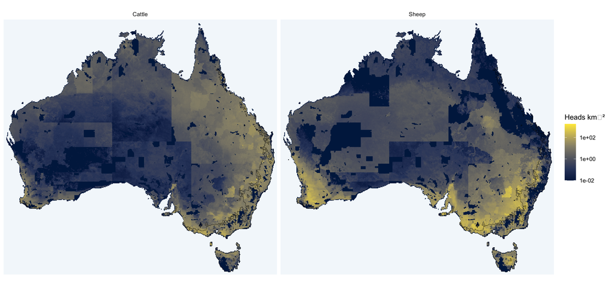

Figure S1: Cattle and sheep densities (GLW3, 2010; heads km⁻², log scale) with the currently suitable range outlined.

```r
save_fig("FigS1_livestock_density", w = 13, h = 6)
```

```r
comp <- bind_rows(map_df(list(g = pmin(pm_cur$G, 3)), tibble(key = "g", v = "Generations per year (G, capped at 3)")),
                  map_df(list(m = pm_cur$M_l), tibble(key = "m", v = "Months suitable for larval questing")),
                  map_df(list(h = pm_cur$H), tibble(key = "h", v = "Heat-stress months (mean Tmax ≥ 35 °C)")),
                  map_df(list(d = pm_cur$D), tibble(key = "d", v = "Dry-stress months (SD > 20 mmHg)")))
plots <- lapply(unique(comp$v), function(vv) ggplot(filter(comp, v == vv)) + geom_raster(aes(x, y, fill = value)) +
  geom_sf(data = aus_sf, fill = NA, colour = "grey40", linewidth = 0.1) + scale_fill_viridis_c(name = NULL) + map_base + labs(title = vv) +
  theme(plot.title = element_text(size = 10), legend.position = "bottom"))
wrap_plots(plots, nrow = 1)
```

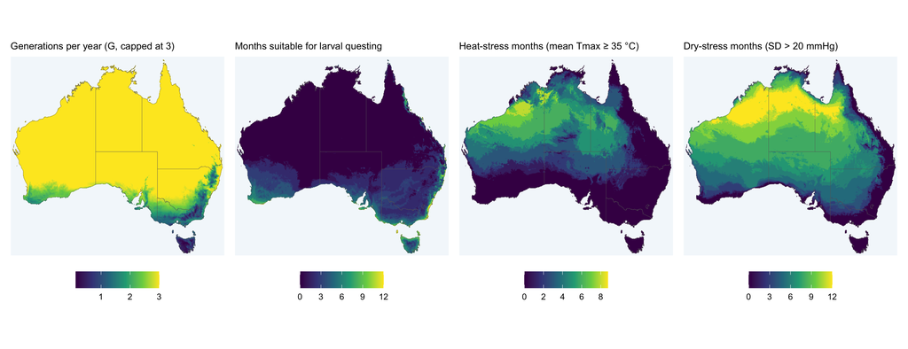

Figure S2: Components of the process-based model under current climate: generations per year (*G*), months suitable for larval questing, heat-stress months and dry-stress months.

```r
save_fig("FigS2_process_components", w = 15, h = 5)
```

```r
scen |> filter(set == "core") |> ggplot(aes(per_mid[as.character(period)], gwl, colour = ssp_l, shape = gwl_capped)) +
  geom_jitter(width = 1.5, height = 0, size = 1.8, alpha = 0.8) + scale_colour_manual(values = ssp_col, name = NULL) +
  scale_shape_manual(values = c(`FALSE` = 16, `TRUE` = 1), labels = c("Interpolated", "Estimated from local warming"), name = NULL) +
  scale_x_continuous(breaks = per_mid, labels = gsub("-", "–", periods)) + labs(x = NULL, y = "Global warming level (°C above 1850–1900)")
```

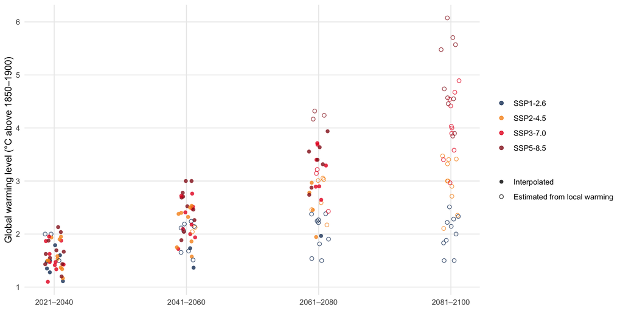

Figure S3: Global warming level assigned to each GCM × SSP × period. Open symbols: estimated from local warming.

```r
save_fig("FigS3_gwl_mapping", w = 10, h = 5)
```

```r
cand |> transmute(x, y, Prior = pi, `Posterior after negative surveys` = post) |> pivot_longer(-c(x, y)) |>
  ggplot() + geom_sf(data = aus_sf, fill = "grey95", colour = NA) + geom_tile(aes(x, y, fill = value), width = 0.25, height = 0.25) +
  geom_sf(data = jur, fill = NA, colour = "grey35", linewidth = 0.1) +
  scale_fill_viridis_c(option = "plasma", trans = "sqrt", name = "Probability") + facet_wrap(~ name) + se_base
```

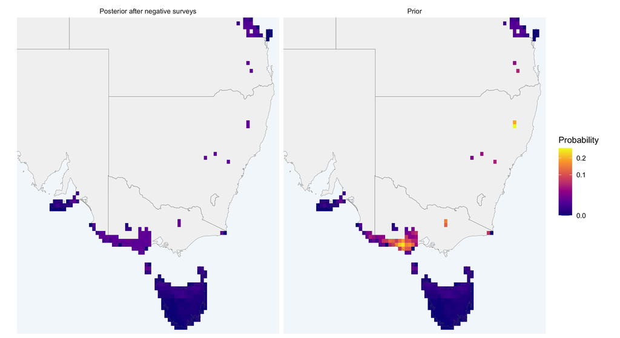

Figure S4: Prior and posterior (after negative surveys under the reference design) probability that a candidate unit harbours an undetected population.

```r
save_fig("FigS4_surveillance_posterior", w = 11, h = 6)
```

## Computational environment

```r
key_results <- list(expo_ens = expo_ens, cost_proj = cost_proj, cost_head = cost_head, units = units, sens_gamma = sens_gamma,
                    surv_curve = surv_curve, surv_jur = surv_jur, pm_auc = pm_auc, pm_agree = pm_agree, sens_K = sens_K,
                    pm_summary = pm_summary, ref_tab = ref_tab, ref_lapse = ref_lapse, gwl_sum = gwl_sum, gwl_year = gwl_year)
saveRDS(key_results, file.path(out_dir, "key_results.rds"))
```